# Mapping Notebook

Map RI scores with light clustering

```r
# ──────────────────────────────────────────────────────────────
# Map RI, RI_post_only, and RI_jsd (if available) with light clusters
#   • Clustering uses n_cert as the "garbage count" proxy
#   • Robust min across 4 windows; min per-cluster threshold = 150
#   • Alaska & Hawaii included via state outlines
# ──────────────────────────────────────────────────────────────

# 0) Packages & options
required <- c("sf","tigris","readr","dplyr","stringr","purrr","ggplot2",
              "here","scales","igraph","tidyr","tibble","patchwork")
missing <- setdiff(required, rownames(installed.packages()))
if (length(missing)) install.packages(missing)
invisible(lapply(required, library, character.only = TRUE))
```

[output not shown]

```r
options(tigris_use_cache = TRUE, tigris_class = "sf")
sf::sf_use_s2(FALSE)
```

```
G3;Spherical geometry (s2) switched off
g
```

```r
`%||%` <- function(a, b) if (!is.null(a)) a else b

# 1) Windows & inputs
periods_vec <- c("1999_2005","2006_2012","2013_2019","2020_2022")
shapefile_years <- c("1999_2005"=2000, "2006_2012"=2010, "2013_2019"=2019, "2020_2022"=2020)

metrics_path_gz <- here::here("data","county_year_quality_metrics.csv.gz")
metrics_path    <- if (file.exists(metrics_path_gz)) metrics_path_gz else here::here("data","county_year_quality_metrics.csv")

dq <- readr::read_csv(metrics_path, show_col_types = FALSE) %>%
  dplyr::mutate(
    year        = suppressWarnings(as.integer(year)),
    county_ihme = stringr::str_pad(as.character(county_ihme), 5, pad = "0"),
    time_window = dplyr::case_when(
      year >= 1999 & year <= 2005 ~ "1999_2005",
      year >= 2006 & year <= 2012 ~ "2006_2012",
      year >= 2013 & year <= 2019 ~ "2013_2019",
      year >= 2020 & year <= 2022 ~ "2020_2022",
      TRUE ~ NA_character_
    ),
    time_window = stringr::str_replace_all(time_window, "[\u2013\u2014]", "_")
  )

# Required columns for this mapping step
req_cols <- c("RI","RI_post_only","n_cert")
stopifnot(all(req_cols %in% names(dq)))

has_jsd <- "RI_jsd" %in% names(dq)
if (!has_jsd) message("ℹ 'RI_jsd' not found in input; JSD maps will be skipped.")

# Use n_cert as garbage proxy
dq$gb_n <- suppressWarnings(as.numeric(dq$n_cert))
dq$gb_n[is.na(dq$gb_n)] <- 0

# 2) IHME crosswalk
load(here::here("data_raw","ihme_fips.rda"))  # -> ihme_fips
ihme_map <- ihme_fips %>%
  dplyr::transmute(
    GEOID       = stringr::str_pad(as.character(orig_fips), 5, pad = "0"),
    county_ihme = stringr::str_pad(as.character(ihme_fips), 5, pad = "0")
  ) %>%
  dplyr::distinct()

# 3) Robust n_cert totals across windows (min across 4)
gb_by_window <- dq %>%
  dplyr::filter(!is.na(time_window)) %>%
  dplyr::group_by(county_ihme, time_window) %>%
  dplyr::summarise(gb = sum(gb_n, na.rm = TRUE), .groups = "drop")

gb_wide <- gb_by_window %>%
  tidyr::pivot_wider(names_from = time_window, values_from = gb, values_fill = 0)
for (w in periods_vec) if (!w %in% names(gb_wide)) gb_wide[[w]] <- 0

robust_tbl <- gb_wide %>%
  dplyr::mutate(robust_gb = pmin(`1999_2005`,`2006_2012`,`2013_2019`,`2020_2022`, na.rm = TRUE)) %>%
  dplyr::transmute(county_ihme, robust_gb = as.numeric(robust_gb))

# 4) Shapefiles
crs_proj <- 2163
albers_5070 <- 5070

normalize_geoid <- function(sfobj, year) {
  nms <- names(sfobj)
  geoid_col <- grep("^GEOID", nms, value = TRUE)[1]
  if (!is.na(geoid_col)) {
    sfobj <- dplyr::rename(sfobj, GEOID = !!rlang::sym(geoid_col))
    sfobj$GEOID <- stringr::str_pad(as.character(sfobj$GEOID), 5, pad = "0")
    return(sfobj)
  }
  state_col  <- grep("^STATE.*FP$", nms, value = TRUE)[1]
  county_col <- grep("^COUNTY.*FP$", nms, value = TRUE)[1]
  if (!is.na(state_col) && !is.na(county_col)) {
    sfobj$GEOID <- paste0(
      stringr::str_pad(as.character(sfobj[[state_col]]),  2, pad = "0"),
      stringr::str_pad(as.character(sfobj[[county_col]]), 3, pad = "0")
    )
    return(sfobj)
  }
  combo_col <- grep("^CNTYIDFP$", nms, value = TRUE)[1]
  if (!is.na(combo_col)) {
    sfobj <- dplyr::rename(sfobj, GEOID = !!rlang::sym(combo_col))
    sfobj$GEOID <- stringr::str_pad(as.character(sfobj$GEOID), 5, pad = "0")
    return(sfobj)
  }
  stop("No GEOID-compatible columns found in shapefile for year ", year)
}

build_ihme_groups_sf <- function(year) {
  counties_raw <- tigris::counties(year = year, cb = TRUE, class = "sf") %>%
    sf::st_zm(drop = TRUE, what = "ZM") %>%
    sf::st_make_valid()
  counties_norm <- normalize_geoid(counties_raw, year) %>%
    sf::st_transform(crs_proj) %>%
    sf::st_make_valid()
  counties_norm %>%
    dplyr::left_join(ihme_map, by = "GEOID") %>%
    dplyr::mutate(county_ihme = dplyr::coalesce(county_ihme, GEOID)) %>%
    dplyr::group_by(county_ihme) %>%
    dplyr::summarise(.groups = "drop")
}

# --------------------------
# Section 5 (clustering) - Build cluster_map from merged all_county_groupings.csv
# --------------------------

# Candidate merged file locations (should already be produced earlier in script)
merged_candidates <- c(
  here::here("data_raw","all_county_groupings.csv"),
  here::here("data","all_county_groupings.csv"),
  here::here("all_county_groupings.csv")
)
merged_file <- merged_candidates[file.exists(merged_candidates)][1]
if (is.na(merged_file) || length(merged_file) == 0) {
  stop("Could not find merged all_county_groupings.csv. Expected at one of: ",
       paste(merged_candidates, collapse = ", "))
}
message("Reading merged file for cluster assignments: ", merged_file)
```

```
G3;Reading merged file for cluster assignments: /Users/amymann/Documents/Data Quality Project/DataQuality/data_raw/all_county_groupings.csv
g
```

```r
# Read merged CSV as character
merged_df <- readr::read_csv(merged_file, col_types = readr::cols(.default = "c"), show_col_types = FALSE)

# Ensure we have a cluster-id column: prefer "CS Area Code", else try "County Set Name"
if (!("CS Area Code" %in% names(merged_df)) && !("County Set Name" %in% names(merged_df))) {
  stop("Merged file must contain a 'CS Area Code' or 'County Set Name' column (filled down).",
       "\nPlease run the cleaning step that fills down group headers before this step.")
}
cluster_col_name <- if ("CS Area Code" %in% names(merged_df)) "CS Area Code" else "County Set Name"

# Ensure FIPS column exists
if (!("FIPS" %in% names(merged_df))) {
  stop("Merged file must contain a 'FIPS' column with county FIPS values (may be empty for header rows).")
}

# Keep only rows with non-empty FIPS (these are county member rows)
members <- merged_df %>%
  dplyr::mutate(
    FIPS_raw = stringr::str_trim(as.character(FIPS)),
    FIPS_digits = ifelse(FIPS_raw == "" | is.na(FIPS_raw), NA_character_, gsub("[^0-9]", "", FIPS_raw)),
    FIPS5 = ifelse(is.na(FIPS_digits), NA_character_, stringr::str_pad(FIPS_digits, width = 5, side = "left", pad = "0")),
    cluster_id = stringr::str_trim(as.character(.data[[cluster_col_name]]))
  ) %>%
  dplyr::filter(!is.na(FIPS5) & FIPS5 != "" & !is.na(cluster_id) & cluster_id != "") %>%
  dplyr::select(FIPS5, cluster_id) %>%
  dplyr::rename(raw_fips = FIPS5)

# Map raw_fips -> county_ihme using ihme_map if present, otherwise treat raw_fips as county_ihme
if (exists("ihme_map")) {
  # ihme_map expected to have columns GEOID and county_ihme (from earlier load)
  if (!("GEOID" %in% names(ihme_map)) || !("county_ihme" %in% names(ihme_map))) {
    # if ihme_map is the raw object format (orig_fips / ihme_fips), coerce accordingly
    if (exists("ihme_fips") && all(c("orig_fips","ihme_fips") %in% names(ihme_fips))) {
      xwalk <- ihme_fips %>%
        dplyr::transmute(GEOID = stringr::str_pad(as.character(orig_fips), 5, pad = "0"),
                         county_ihme = stringr::str_pad(as.character(ihme_fips), 5, pad = "0"))
    } else {
      stop("ihme_map present but does not have expected structure. Please ensure ihme_fips / ihme_map is loaded correctly.")
    }
  } else {
    xwalk <- ihme_map %>% dplyr::transmute(GEOID = stringr::str_pad(as.character(GEOID), 5, pad = "0"),
                                          county_ihme = stringr::str_pad(as.character(county_ihme), 5, pad = "0"))
  }

  members2 <- members %>%
    dplyr::left_join(xwalk, by = c("raw_fips" = "GEOID")) %>%
    dplyr::mutate(county_ihme = dplyr::coalesce(county_ihme, raw_fips)) %>%
    dplyr::select(county_ihme, cluster_id)
} else {
  # No crosswalk available; use raw FIPS as county_ihme
  members2 <- members %>%
    dplyr::mutate(county_ihme = raw_fips) %>%
    dplyr::select(county_ihme, cluster_id)
}

# Build cluster_map and sanity-checks
cluster_map <- members2 %>%
  dplyr::mutate(county_ihme = stringr::str_pad(as.character(county_ihme), 5, pad = "0"),
                cluster_id = as.character(cluster_id)) %>%
  dplyr::distinct(county_ihme, cluster_id)

if (nrow(cluster_map) == 0) stop("No valid county->cluster mappings found in merged file.")

# Check for counties mapped to >1 cluster (shouldn't happen)
dup_check <- cluster_map %>%
  dplyr::group_by(county_ihme) %>%
  dplyr::summarise(n = dplyr::n(), clusters = paste(sort(unique(cluster_id)), collapse = ";"), .groups = "drop") %>%
  dplyr::filter(n > 1)

if (nrow(dup_check) > 0) {
  stop("Found counties assigned to multiple clusters (first 20 shown):\n", paste0(utils::capture.output(head(dup_check, 20)), collapse = "\n"),
       "\nPlease fix the merged CSV so each county FIPS appears under only one CS Area Code.")
}
```

| county_ihme | n | clusters |
| --- | --- | --- |
| 04012 | 2 | 04CS005;04CS011 |
| 08001 | 6 | 08CS001;08CS002;08CS003;08CS007;08CS013;08CS023 |
| 24031 | 2 | 24CS014;24CS015 |
| 35006 | 2 | 35CS002;35CS017 |
| 51199 | 2 | 51CS034;51CS052 |

[output not shown]

```r
# --------------------------
#  Section 6
# --------------------------

agg_metric <- function(varname) {
  dq %>%
    dplyr::filter(!is.na(time_window)) %>%
    dplyr::inner_join(cluster_map, by = "county_ihme") %>%
    dplyr::group_by(cluster_id, time_window) %>%
    dplyr::summarise(val = mean(.data[[varname]], na.rm = TRUE),
                     n_counties = dplyr::n_distinct(county_ihme),
                     .groups = "drop") %>%
    tidyr::complete(cluster_id, time_window = periods_vec,
                    fill = list(val = NA_real_, n_counties = 0L))
}

dq_cluster_RI   <- agg_metric("RI") %>% dplyr::rename(RI = val)
```

```
G2;H2;Warningh in dplyr::inner_join(., cluster_map, by = "county_ihme") :
  Detected an unexpected many-to-many relationship between `x` and `y`.
ℹ Row 96 of `x` matches multiple rows in `y`.
ℹ Row 1 of `y` matches multiple rows in `x`.
ℹ If a many-to-many relationship is expected, set `relationship = "many-to-many"` to silence this warning.g
```

```r
dq_cluster_post <- agg_metric("RI_post_only") %>% dplyr::rename(RI_post_only = val)
```

```
G2;H2;Warningh in dplyr::inner_join(., cluster_map, by = "county_ihme") :
  Detected an unexpected many-to-many relationship between `x` and `y`.
ℹ Row 96 of `x` matches multiple rows in `y`.
ℹ Row 1 of `y` matches multiple rows in `x`.
ℹ If a many-to-many relationship is expected, set `relationship = "many-to-many"` to silence this warning.g
```

```r
dq_cluster_jsd  <- if (has_jsd) agg_metric("RI_jsd") %>% dplyr::rename(RI_jsd = val) else NULL
```

```
G2;H2;Warningh in dplyr::inner_join(., cluster_map, by = "county_ihme") :
  Detected an unexpected many-to-many relationship between `x` and `y`.
ℹ Row 96 of `x` matches multiple rows in `y`.
ℹ Row 1 of `y` matches multiple rows in `x`.
ℹ If a many-to-many relationship is expected, set `relationship = "many-to-many"` to silence this warning.g
```

```r
# 7) Shapes per period
build_clusters_sf <- function(year) {
  base <- build_ihme_groups_sf(year)
  base %>%
    dplyr::left_join(cluster_map, by = "county_ihme") %>%
    dplyr::filter(!is.na(cluster_id)) %>%
    dplyr::group_by(cluster_id) %>%
    dplyr::summarise(.groups = "drop") %>%
    sf::st_transform(crs_proj) %>%
    sf::st_make_valid()
}

join_shapes <- function(metric_df) {
  lapply(names(shapefile_years), function(window) {
    year <- unname(shapefile_years[[window]])
    shape_all <- build_clusters_sf(year)
    dplyr::left_join(shape_all, dplyr::filter(metric_df, time_window == window), by = "cluster_id")
  }) %>% setNames(names(shapefile_years))
}

joined_by_period_RI   <- join_shapes(dq_cluster_RI)
```

```
G3;although coordinates are longitude/latitude, st_union assumes that they are planar
gG2;H2;Warningh in CPL_crs_from_input(x) :
  GDAL Message 1: CRS EPSG:2163 is deprecated. Its non-deprecated replacement EPSG:9311 will be used instead. To use the original CRS, set the OSR_USE_NON_DEPRECATED configuration option to NO.g
```

```r
joined_by_period_post <- join_shapes(dq_cluster_post)
```

```
G3;although coordinates are longitude/latitude, st_union assumes that they are planar
g
```

```r
joined_by_period_jsd  <- if (!is.null(dq_cluster_jsd)) join_shapes(dq_cluster_jsd) else NULL
```

```
G3;although coordinates are longitude/latitude, st_union assumes that they are planar
g
```

```r
# 8) Map helpers (fixed limits)
states_outline <- tigris::states(cb = TRUE, class = "sf") |>
  sf::st_transform(crs_proj) |>
  sf::st_make_valid()
```

```
G3;Retrieving data for the year 2024
g
```

```r
make_map_numeric <- function(sf_data, fill_col, limits, title) {
  ggplot() +
    geom_sf(data = sf_data, aes(fill = .data[[fill_col]]), colour = NA) +
    geom_sf(data = states_outline, fill = NA, colour = "white", linewidth = 0.3) +
    scale_fill_distiller(palette = "RdBu", limits = limits,
                         oob = scales::squish, direction = 1,
                         na.value = "grey90") +
    coord_sf(xlim = c(-2500000, 2500000), ylim = c(-2200000, 730000), expand = FALSE) +
    labs(title = title, fill = NULL) +
    theme_void() +
    theme(plot.title = element_text(size = 16, face = "bold", hjust = 0.5),
          legend.text = element_text(size = 9))
}

make_map_RI   <- function(sf_data, title) make_map_numeric(sf_data, "RI", c(0.018, 0.04), title)
make_map_post <- function(sf_data, title) make_map_numeric(sf_data, "RI_post_only", c(0.12, 0.19), title)
make_map_jsd  <- function(sf_data, title) make_map_numeric(sf_data, "RI_jsd", c(0.015, 0.03), title)  # tweak if needed

# 9) Save maps
output_dir <- here::here("figures", "5yr_avg_stable")
dir.create(output_dir, showWarnings = FALSE, recursive = TRUE)

# RI maps
p_1999_RI <- make_map_RI(joined_by_period_RI[["1999_2005"]], "1999_2005")
p_2006_RI <- make_map_RI(joined_by_period_RI[["2006_2012"]], "2006_2012")
p_2013_RI <- make_map_RI(joined_by_period_RI[["2013_2019"]], "2013_2019")
p_2020_RI <- make_map_RI(joined_by_period_RI[["2020_2022"]], "2020_2022")
combined_RI <- (p_1999_RI | p_2006_RI) / (p_2013_RI | p_2020_RI)
```

|  | t | l | b | r |
| --- | --- | --- | --- | --- |
| 1: | 1 | 1 | 1 | 1 |
| 2: | 1 | 2 | 1 | 2 |

```r
ggsave(file.path(output_dir, "RI_clustered_garbage150_4panel.png"),
       plot = combined_RI, width = 12, height = 9, dpi = 320)

# RI_post_only maps
p_1999_post <- make_map_post(joined_by_period_post[["1999_2005"]], "1999_2005")
p_2006_post <- make_map_post(joined_by_period_post[["2006_2012"]], "2006_2012")
p_2013_post <- make_map_post(joined_by_period_post[["2013_2019"]], "2013_2019")
p_2020_post <- make_map_post(joined_by_period_post[["2020_2022"]], "2020_2022")
combined_post <- (p_1999_post | p_2006_post) / (p_2013_post | p_2020_post)
```

|  | t | l | b | r |
| --- | --- | --- | --- | --- |
| 1: | 1 | 1 | 1 | 1 |
| 2: | 1 | 2 | 1 | 2 |

```r
ggsave(file.path(output_dir, "RI_post_only_clustered_garbage150_4panel.png"),
       plot = combined_post, width = 12, height = 9, dpi = 320)

# RI_jsd maps (if available)
if (!is.null(joined_by_period_jsd)) {
  p_1999_jsd <- make_map_jsd(joined_by_period_jsd[["1999_2005"]], "1999_2005")
  p_2006_jsd <- make_map_jsd(joined_by_period_jsd[["2006_2012"]], "2006_2012")
  p_2013_jsd <- make_map_jsd(joined_by_period_jsd[["2013_2019"]], "2013_2019")
  p_2020_jsd <- make_map_jsd(joined_by_period_jsd[["2020_2022"]], "2020_2022")
  combined_jsd <- (p_1999_jsd | p_2006_jsd) / (p_2013_jsd | p_2020_jsd)
  ggsave(file.path(output_dir, "RI_jsd_clustered_garbage150_4panel.png"),
         plot = combined_jsd, width = 12, height = 9, dpi = 320)
} else {
  message("⚠ Skipping JSD maps: 'RI_jsd' not present in input file.")
}
```

|  | t | l | b | r |
| --- | --- | --- | --- | --- |
| 1: | 1 | 1 | 1 | 1 |
| 2: | 1 | 2 | 1 | 2 |

```r
message("✓ Done. Maps saved to: ", output_dir)
```

```
G3;✓ Done. Maps saved to: /Users/amymann/Documents/Data Quality Project/DataQuality/figures/5yr_avg_stable
g
```

NEW: Make a new plot with RI maps and level of detail for new paper

```r
#!/usr/bin/env Rscript
# 4 maps: RI (1999–2005, 2020–2022) on top + LOD (UCOD 4-digit standardized diversity) on bottom
# - RI uses standard county->cluster membership (membership_ri_file)
# - LOD uses cluster membership FROM YOUR LIST (membership_lod_file) so boundaries can differ
# - LOD polygons & styling emulate your LOD code (inner_join + st_union, Reds palette, simple period titles)
# - Output → figures/5yr_avg_stable/ri_lod_2x2.png

suppressPackageStartupMessages({
  pkgs <- c("sf","dplyr","stringr","readr","ggplot2","tigris",
            "rlang","purrr","patchwork","scales","here")
  miss <- setdiff(pkgs, rownames(installed.packages()))
  if (length(miss)) install.packages(miss, repos = "https://cloud.r-project.org")
  lapply(pkgs, library, character.only = TRUE)
})
```

[output not shown]

```r
options(tigris_use_cache = TRUE, tigris_class = "sf", sf_use_s2 = TRUE)

# ------------------------ paths -------------------------------
metrics_file          <- here::here("output", "cluster_metrics_ucr39_cstd.csv.gz")   # cluster-level LOD metric
membership_ri_file   <- here::here("output", "county_cluster_membership.csv.gz")       # RI membership
membership_lod_candidates <- c(                                                        # LOD membership from your list
  here::here("data", "all_county_groupings.csv"),
  here::here("data", "all_county_groupings.csv.gz"),
  here::here("output","county_cluster_membership.csv.gz") # last-resort fallback
)
membership_lod_file <- membership_lod_candidates[file.exists(membership_lod_candidates)][1]

metrics2_file        <- here::here("data",   "county_year_quality_metrics.csv.gz")     # contains RI_post_only by fips/year/period
out_dir_base         <- here::here("figures", "5yr_avg_stable")
diag_dir             <- file.path(out_dir_base, "diagnostics")
dir.create(out_dir_base, recursive = TRUE, showWarnings = FALSE)
dir.create(diag_dir, recursive = TRUE, showWarnings = FALSE)

# -------------------- projection & periods --------------------
crs_proj    <- 2163
periods_two <- c("1999_2005","2020_2022")

# ------------------------ helpers -----------------------------
std_fips_vec <- function(x) stringr::str_pad(as.character(x), 5, pad = "0")

st_shift <- function(sf_obj, shift = c(0, 0)) { st_geometry(sf_obj) <- st_geometry(sf_obj) + shift; sf_obj }
st_scale <- function(sf_obj, scale = 1) {
  centroid <- st_centroid(st_union(sf_obj))
  st_geometry(sf_obj) <- (st_geometry(sf_obj) - centroid) * scale + centroid
  sf_obj
}

build_counties_2163_resized <- function() {
  us_counties <- tigris::counties(year = 2020, cb = TRUE, class = "sf") |>
    sf::st_transform(crs_proj) |>
    dplyr::select(GEOID, STATEFP, geometry)

  mainland <- us_counties |> dplyr::filter(!STATEFP %in% c("02","15"))
  alaska   <- us_counties |> dplyr::filter(STATEFP == "02") |>
               st_scale(0.33) |> st_shift(c(1100000, -4700000)) |> sf::st_set_crs(crs_proj)
  hawaii   <- us_counties |> dplyr::filter(STATEFP == "15") |>
               st_scale(1)    |> st_shift(c(5000000, -1100000)) |> sf::st_set_crs(crs_proj)

  dplyr::bind_rows(mainland, alaska, hawaii) |>
    dplyr::rename(fips = GEOID, statefp = STATEFP) |>
    sf::st_make_valid() |>
    (\(x){ sf::st_crs(x) <- crs_proj; x })() |>
    (\(x){ x$fips <- std_fips_vec(x$fips); x })()
}

build_states_2163_resized <- function() {
  us_states <- tigris::states(year = 2020, cb = TRUE, class = "sf") |>
    sf::st_transform(crs_proj) |>
    dplyr::select(STATEFP, geometry)

  mainland <- us_states |> dplyr::filter(!STATEFP %in% c("02","15"))
  alaska   <- us_states |> dplyr::filter(STATEFP == "02") |>
               st_scale(0.33) |> st_shift(c(1100000, -4700000)) |> sf::st_set_crs(crs_proj)
  hawaii   <- us_states |> dplyr::filter(STATEFP == "15") |>
               st_scale(1)    |> st_shift(c(5000000, -1100000)) |> sf::st_set_crs(crs_proj)

  dplyr::bind_rows(mainland, alaska, hawaii) |>
    sf::st_make_valid() |>
    (\(x){ sf::st_crs(x) <- crs_proj; x })()
}

# ----- Membership normalisers -----
norm_membership_ri <- function(df) {
  nms <- names(df); low <- tolower(nms)
  fips_col    <- nms[which(grepl("^(fips|geoid)$|^geoid|fips", low))[1]]
  cluster_col <- nms[which(grepl("^(cluster|cluster_id)$|cluster", low))[1]]
  period_col  <- nms[low == "period"]
  if (is.na(fips_col) || is.na(cluster_col) || !length(period_col))
    stop("RI membership needs fips, cluster, period.")
  df |>
    dplyr::transmute(
      fips    = std_fips_vec(.data[[fips_col]]),
      cluster = as.character(.data[[cluster_col]]),
      period  = as.character(.data[[period_col]])
    ) |>
    dplyr::distinct()
}

norm_membership_lod <- function(df, periods_two) {
  nms <- names(df); low <- tolower(nms)
  fips_col    <- nms[which(grepl("^(fips|geoid)$|^geoid|fips", low))[1]]
  cluster_col <- nms[which(grepl("^(cluster|group|cluster_id)$|cluster|group", low))[1]]
  period_col  <- nms[low == "period"]
  if (is.na(fips_col) || is.na(cluster_col))
    stop("LOD membership needs fips and cluster/group (period optional).")
  base <- df |>
    dplyr::transmute(fips = std_fips_vec(.data[[fips_col]]),
                     cluster = as.character(.data[[cluster_col]])) |>
    dplyr::distinct()
  if (length(period_col)) {
    df |>
      dplyr::transmute(
        fips    = std_fips_vec(.data[[fips_col]]),
        cluster = as.character(.data[[cluster_col]]),
        period  = as.character(.data[[period_col]])
      ) |>
      dplyr::distinct()
  } else {
    purrr::map_dfr(periods_two, ~ dplyr::mutate(base, period = .x))
  }
}

# ----- Cluster polygon builders -----
# RI: robust (ok to keep your previous approach)
build_cluster_sf_ri <- function(period_key, membership_df, counties_sf) {
  mm <- membership_df |>
    dplyr::filter(period == period_key) |>
    dplyr::transmute(fips = std_fips_vec(fips), cluster = as.character(cluster)) |>
    dplyr::distinct()
  if (!nrow(mm)) stop("No RI membership rows for period: ", period_key)
  joined <- dplyr::inner_join(counties_sf, mm, by = c("fips" = "fips"))
  joined |>
    dplyr::group_by(cluster) |>
    dplyr::summarise(geometry = sf::st_union(geometry), .groups = "drop") |>
    sf::st_make_valid()
}

# LOD: EXACTLY like your LOD code (inner_join counties + membership → union by cluster)
build_cluster_sf_lod <- function(period_key, membership_df, counties_sf) {
  mm <- membership_df |>
    dplyr::filter(.data$period == period_key) |>
    dplyr::transmute(fips = std_fips_vec(as.character(fips)),
                     cluster = as.character(cluster)) |>
    dplyr::distinct()
  if (!nrow(mm)) stop("No LOD membership rows for period: ", period_key)
  counties_sf |>
    dplyr::inner_join(mm, by = "fips") |>
    dplyr::group_by(cluster) |>
    dplyr::summarise(geometry = sf::st_union(geometry), .groups = "drop") |>
    sf::st_make_valid()
}

# ------------------------- load data --------------------------
if (!file.exists(metrics_file)) stop("Missing metrics_file: ", metrics_file)
if (!file.exists(membership_ri_file)) {
  alt <- sub("\\.csv$", ".csv.gz", membership_ri_file)
  if (file.exists(alt)) membership_ri_file <- alt else stop("Missing membership_ri_file: ", membership_ri_file)
}
if (is.na(membership_lod_file) || !file.exists(membership_lod_file))
  stop("Could not find a LOD membership list. Checked: ", paste(membership_lod_candidates, collapse = "; "))
if (!file.exists(metrics2_file)) stop("Missing metrics2_file: ", metrics2_file)

message("Reading LOD metrics: ", metrics_file)
```

```
G3;Reading LOD metrics: /Users/amymann/Documents/Data Quality Project/DataQuality/output/cluster_metrics_ucr39_cstd.csv.gz
g
```

```r
metrics <- readr::read_csv(metrics_file, show_col_types = FALSE) |>
  dplyr::mutate(cluster = as.character(cluster), period = as.character(period))

message("Reading RI membership: ", membership_ri_file)
```

```
G3;Reading RI membership: /Users/amymann/Documents/Data Quality Project/DataQuality/output/county_cluster_membership.csv.gz
g
```

```r
membership_ri <- readr::read_csv(membership_ri_file, show_col_types = FALSE)

message("Reading LOD list membership: ", membership_lod_file)
```

```
G3;Reading LOD list membership: /Users/amymann/Documents/Data Quality Project/DataQuality/output/county_cluster_membership.csv.gz
g
```

```r
membership_lod_raw <- readr::read_csv(membership_lod_file, show_col_types = FALSE)

message("Reading county-year quality metrics (RI): ", metrics2_file)
```

```
G3;Reading county-year quality metrics (RI): /Users/amymann/Documents/Data Quality Project/DataQuality/data/county_year_quality_metrics.csv.gz
g
```

```r
metrics2_raw <- readr::read_csv(metrics2_file, show_col_types = FALSE)

# normalise memberships
membership_ri  <- norm_membership_ri(membership_ri)
membership_lod <- norm_membership_lod(membership_lod_raw, periods_two)

# geographies
counties_tf <- build_counties_2163_resized()
states_tf   <- build_states_2163_resized()

# ---------------------- select the UCOD metric (LOD) -----------
ucod_col <- "detail_ucod_icd4_cstd"
if (!ucod_col %in% names(metrics)) stop("Column 'detail_ucod_icd4_cstd' not found in metrics.")
metrics_lod_two <- metrics |>
  dplyr::filter(period %in% periods_two) |>
  dplyr::select(cluster, period, !!rlang::sym(ucod_col)) |>
  dplyr::rename(lod_value = !!rlang::sym(ucod_col))

# ------------------ aggregate RI to cluster-period -------------
# detect id/time/ri columns robustly
possible_id_cols <- c("fips","geoid","county_ihme","county")
lower_names <- tolower(names(metrics2_raw))
id_idx <- which(lower_names %in% possible_id_cols)[1]
if (is.na(id_idx)) stop("Could not find an ID column in metrics2_file.")
id_col <- names(metrics2_raw)[id_idx]

ri_candidates <- c("RI_post_only")
ri_idx <- which(tolower(names(metrics2_raw)) %in% tolower(ri_candidates))[1]
if (is.na(ri_idx)) stop("Could not find an RI column in metrics2_file.")
ri_col <- names(metrics2_raw)[ri_idx]

time_col <- if ("period" %in% names(metrics2_raw)) {
  "period"
} else if ("year" %in% names(metrics2_raw)) {
  "year"
} else {
  stop("metrics2 must have 'period' or 'year'.")
}

metrics2 <- metrics2_raw |>
  dplyr::mutate(id_str = std_fips_vec(.data[[id_col]]))

if (time_col == "year") {
  metrics2 <- metrics2 |>
    dplyr::mutate(
      year = as.integer(.data$year),
      period = dplyr::case_when(
        year >= 1999 & year <= 2005 ~ "1999_2005",
        year >= 2006 & year <= 2012 ~ "2006_2012",
        year >= 2013 & year <= 2019 ~ "2013_2019",
        year >= 2020 & year <= 2022 ~ "2020_2022",
        TRUE ~ NA_character_
      )
    )
} else {
  metrics2 <- metrics2 |> dplyr::mutate(period = as.character(.data$period))
}

metrics2_agg <- metrics2 |>
  dplyr::transmute(fips = id_str, period = period, RI_post_only = as.numeric(.data[[ri_col]])) |>
  dplyr::filter(!is.na(fips), !is.na(period)) |>
  dplyr::group_by(fips, period) |>
  dplyr::summarise(RI_post_only = mean(RI_post_only, na.rm = TRUE), .groups = "drop")

# RI cluster means
ri_join <- membership_ri |>
  dplyr::left_join(metrics2_agg, by = c("fips","period"))
cluster_ri <- ri_join |>
  dplyr::group_by(cluster, period) |>
  dplyr::summarise(RI_post_only = mean(RI_post_only, na.rm = TRUE), .groups = "drop")

# ----------------- common limits across periods ----------------
ri_vals  <- cluster_ri      |> dplyr::filter(period %in% periods_two) |> dplyr::pull(RI_post_only) |> (\(x) x[is.finite(x)])()
lod_vals <- metrics_lod_two |> dplyr::pull(lod_value)                 |> (\(x) x[is.finite(x)])()
ri_lims  <- if (length(ri_vals)  >= 3) stats::quantile(ri_vals,  c(0.01,0.99), na.rm = TRUE) else range(ri_vals,  na.rm = TRUE)
lod_lims <- if (length(lod_vals) >= 3) stats::quantile(lod_vals, c(0.02,0.98), na.rm = TRUE) else range(lod_vals, na.rm = TRUE)

message("Building RI polygons (RI membership) ...")
```

```
G3;Building RI polygons (RI membership) ...
g
```

```r
cl_sf_1999_ri <- build_cluster_sf_ri ("1999_2005", membership_ri,  counties_tf)
cl_sf_2020_ri <- build_cluster_sf_ri ("2020_2022", membership_ri,  counties_tf)

message("Building LOD polygons (LIST membership; different boundaries) ...")
```

```
G3;Building LOD polygons (LIST membership; different boundaries) ...
g
```

```r
cl_sf_1999_lod <- build_cluster_sf_lod("1999_2005", membership_lod, counties_tf)
cl_sf_2020_lod <- build_cluster_sf_lod("2020_2022", membership_lod, counties_tf)

# ------------------------- join metrics ------------------------
map_ri_1999  <- cl_sf_1999_ri  |> dplyr::left_join(cluster_ri      |> dplyr::filter(period == "1999_2005") |> dplyr::select(cluster, RI_post_only), by = "cluster")
map_ri_2020  <- cl_sf_2020_ri  |> dplyr::left_join(cluster_ri      |> dplyr::filter(period == "2020_2022") |> dplyr::select(cluster, RI_post_only), by = "cluster")
map_lod_1999 <- cl_sf_1999_lod |> dplyr::left_join(metrics_lod_two |> dplyr::filter(period == "1999_2005") |> dplyr::select(cluster, lod_value), by = "cluster")
map_lod_2020 <- cl_sf_2020_lod |> dplyr::left_join(metrics_lod_two |> dplyr::filter(period == "2020_2022") |> dplyr::select(cluster, lod_value), by = "cluster")

# ------------------------- plotting ----------------------------
base_extent <- list(xlim = c(-2500000, 2500000), ylim = c(-2200000, 730000))
make_red_scale <- function(lims) scale_fill_distiller(palette = "Reds", direction = -1, limits = lims, oob = scales::squish, na.value = "grey90")

p_ri_a <- ggplot() +
  geom_sf(data = map_ri_1999, aes(fill = RI_post_only), colour = NA) +
  geom_sf(data = states_tf, fill = NA, colour = "white", linewidth = 0.3) +
  make_red_scale(ri_lims) +
  coord_sf(xlim = base_extent$xlim, ylim = base_extent$ylim, expand = FALSE) +
  labs(title = "Re-assignment Index, 1999–2005", fill = NULL) +
  theme_void(base_size = 11) + theme(plot.title = element_text(hjust = 0.5, face = "bold"))

p_ri_b <- ggplot() +
  geom_sf(data = map_ri_2020, aes(fill = RI_post_only), colour = NA) +
  geom_sf(data = states_tf, fill = NA, colour = "white", linewidth = 0.3) +
  make_red_scale(ri_lims) +
  coord_sf(xlim = base_extent$xlim, ylim = base_extent$ylim, expand = FALSE) +
  labs(title = "Re-assignment Index, 2020–2022", fill = NULL) +
  theme_void(base_size = 11) + theme(plot.title = element_text(hjust = 0.5, face = "bold"))

# LOD: emulate your LOD code (Reds palette, simple titles)
p_lod_a <- ggplot() +
  geom_sf(data = map_lod_1999, aes(fill = lod_value), colour = NA) +
  geom_sf(data = states_tf, fill = NA, colour = "white", linewidth = 0.3) +
  make_red_scale(lod_lims) +
  coord_sf(xlim = base_extent$xlim, ylim = base_extent$ylim, expand = FALSE) +
  labs(title = "Level of detail, 1999–2005", fill = NULL) +
  theme_void(base_size = 11) + theme(plot.title = element_text(hjust = 0.5, face = "bold"))

p_lod_b <- ggplot() +
  geom_sf(data = map_lod_2020, aes(fill = lod_value), colour = NA) +
  geom_sf(data = states_tf, fill = NA, colour = "white", linewidth = 0.3) +
  make_red_scale(lod_lims) +
  coord_sf(xlim = base_extent$xlim, ylim = base_extent$ylim, expand = FALSE) +
  labs(title = "Level of detail, 2020–2022", fill = NULL) +
  theme_void(base_size = 11) + theme(plot.title = element_text(hjust = 0.5, face = "bold"))

# ----------------------- assemble & save -----------------------
layout_plot <- (p_ri_a | p_ri_b) / (p_lod_a | p_lod_b) + patchwork::plot_annotation(tag_levels = "A")
```

|  | t | l | b | r |
| --- | --- | --- | --- | --- |
| 1: | 1 | 1 | 1 | 1 |
| 2: | 1 | 2 | 1 | 2 |

```r
outfile <- file.path(out_dir_base, "ri_lod_2x2.png")
ggsave(outfile, layout_plot, width = 12, height = 10, dpi = 320)
message("✓ Saved: ", outfile)

# (Optional) write polygons for inspection
dir.create(diag_dir, showWarnings = FALSE, recursive = TRUE)
sf::st_write(cl_sf_1999_ri  |> dplyr::mutate(period = "1999_2005"), file.path(diag_dir, "RI_clusters_1999_2005.geojson"),  delete_dsn = TRUE, quiet = TRUE)
sf::st_write(cl_sf_2020_ri  |> dplyr::mutate(period = "2020_2022"), file.path(diag_dir, "RI_clusters_2020_2022.geojson"),  delete_dsn = TRUE, quiet = TRUE)
sf::st_write(cl_sf_1999_lod |> dplyr::mutate(period = "1999_2005"), file.path(diag_dir, "LOD_clusters_1999_2005.geojson"), delete_dsn = TRUE, quiet = TRUE)
sf::st_write(cl_sf_2020_lod |> dplyr::mutate(period = "2020_2022"), file.path(diag_dir, "LOD_clusters_2020_2022.geojson"), delete_dsn = TRUE, quiet = TRUE)
message("Done.")

# -------------------- period summaries (print + save) --------------------
# Summarise cluster-level RI (cluster_ri) and LOD (metrics_lod_two) by the two periods.

summarise_index <- function(df, val_col, period_col = "period") {
  val_sym <- rlang::sym(val_col)
  df %>%
    dplyr::filter(.data[[period_col]] %in% periods_two) %>%
    dplyr::group_by(period = .data[[period_col]]) %>%
    dplyr::summarise(
      n_clusters = sum(!is.na(!!val_sym)),
      p25        = ifelse(n_clusters>0, as.numeric(stats::quantile(!!val_sym, 0.25, na.rm = TRUE)), NA_real_),
      median     = ifelse(n_clusters>0, as.numeric(stats::quantile(!!val_sym, 0.5, na.rm = TRUE)), NA_real_),
      p75        = ifelse(n_clusters>0, as.numeric(stats::quantile(!!val_sym, 0.75, na.rm = TRUE)), NA_real_),
      IQR        = ifelse(n_clusters>0, as.numeric(p75 - p25), NA_real_),
      mean       = ifelse(n_clusters>0, mean(!!val_sym, na.rm = TRUE), NA_real_),
      sd         = ifelse(n_clusters>0, sd(!!val_sym, na.rm = TRUE), NA_real_),
      min        = ifelse(n_clusters>0, min(!!val_sym, na.rm = TRUE), NA_real_),
      max        = ifelse(n_clusters>0, max(!!val_sym, na.rm = TRUE), NA_real_),
      .groups = "drop"
    ) %>%
    # Ensure NaN -> NA and p25/p75/IQR numeric
    dplyr::mutate(across(c(p25, median, p75, IQR, mean, sd, min, max), ~ ifelse(is.nan(.x), NA_real_, as.numeric(.x))))
}

ri_summary  <- summarise_index(cluster_ri,    "RI_post_only", period_col = "period") %>% dplyr::mutate(index = "RI_post_only")
lod_summary <- summarise_index(metrics_lod_two,"lod_value",     period_col = "period") %>% dplyr::mutate(index = "lod_value")

summary_tbl <- dplyr::bind_rows(ri_summary, lod_summary) %>%
  dplyr::select(index, period, n_clusters, p25, median, p75, IQR, mean, sd, min, max)

# print nicely to console
message("---- RI + LOD summaries by period (including IQR) ----")
print(summary_tbl)
```

| index | period | n_clusters | p25 | median | p75 | IQR | mean | sd | min | max |
| --- | --- | --- | --- | --- | --- | --- | --- | --- | --- | --- |
| RI_post_only | 1999_2005 | 1420 | 0.1499231 | 0.1563343 | 0.1630987 | 0.01317563 | 0.1563286 | 0.010161367 | 0.12239093 | 0.1927273 |
| RI_post_only | 2020_2022 | 1420 | 0.1240268 | 0.1300445 | 0.1366804 | 0.01265360 | 0.1305217 | 0.009860503 | 0.09831226 | 0.1628732 |
| lod_value | 1999_2005 | 1420 | 49.5794079 | 50.3350626 | 51.2893378 | 1.70992992 | 50.4923580 | 1.322269765 | 45.01238019 | 53.9208183 |
| lod_value | 2020_2022 | 1421 | 52.8198384 | 54.0824410 | 55.5517390 | 2.73190054 | 54.1880685 | 2.416752652 | 0.00000000 | 59.2145354 |

```r
# save CSV for reproducibility / figures folder
summary_outfile <- file.path(out_dir_base, "ri_lod_summary_by_period.csv")
readr::write_csv(summary_tbl, summary_outfile)
message("Saved summary CSV: ", summary_outfile)
```

NEW: Make a figure with 3 plots of proportion garbage over 3 time periods

```r
# ──────────────────────────────────────────────────────────────
# 3 maps: prop_garbage (1999–2005, 2013–2019, 2020–2022)
#   • Same workflow as RI: county-year → county-period → join membership → cluster means
#   • AK/HI resized; common 2–98% limits across all three panels
#   • Output → figures/5yr_avg_stable/prop_garbage_3maps.png
# ──────────────────────────────────────────────────────────────

suppressPackageStartupMessages({
  pkgs <- c("sf","dplyr","stringr","readr","ggplot2","tigris","rlang","patchwork","scales","here")
  missing <- setdiff(pkgs, rownames(installed.packages()))
  if (length(missing)) install.packages(missing, repos = "https://cloud.r-project.org")
  lapply(pkgs, library, character.only = TRUE)
})
```

[output not shown]

```r
options(tigris_use_cache = TRUE, tigris_class = "sf")
sf::sf_use_s2(FALSE)
```

```
G3;Spherical geometry (s2) switched off
g
```

```r
# ------------------------- paths -------------------------
membership_file <- here::here("output","county_cluster_membership.csv.gz")
metrics2_file   <- here::here("data",  "county_year_quality_metrics.csv.gz")
out_dir_base    <- here::here("figures","5yr_avg_stable")
diag_dir        <- file.path(out_dir_base, "diagnostics")
dir.create(out_dir_base, recursive = TRUE, showWarnings = FALSE)
dir.create(diag_dir, recursive = TRUE, showWarnings = FALSE)

# ---------------------- helpers & geos ----------------------
crs_proj <- 2163
periods_three <- c("1999_2005","2013_2019","2020_2022")
std_fips_vec <- function(x) stringr::str_pad(as.character(x), 5, pad = "0")
st_shift <- function(sf_obj, shift = c(0,0)) { st_geometry(sf_obj) <- st_geometry(sf_obj) + shift; sf_obj }
st_scale <- function(sf_obj, scale = 1) { ctd <- st_centroid(st_union(sf_obj)); st_geometry(sf_obj) <- (st_geometry(sf_obj) - ctd) * scale + ctd; sf_obj }

build_counties_2163_resized <- function() {
  us_counties <- tigris::counties(year = 2020, cb = TRUE, class = "sf") |>
    sf::st_zm(drop = TRUE, what = "ZM") |>
    sf::st_transform(crs_proj) |>
    dplyr::select(GEOID, STATEFP, geometry)
  mainland <- us_counties |> dplyr::filter(!STATEFP %in% c("02","15"))
  alaska   <- us_counties |> dplyr::filter(STATEFP == "02") |> st_scale(0.33) |> st_shift(c(1100000,-4700000)) |> sf::st_set_crs(crs_proj)
  hawaii   <- us_counties |> dplyr::filter(STATEFP == "15") |> st_scale(1.00) |> st_shift(c(5000000,-1100000)) |> sf::st_set_crs(crs_proj)
  out <- dplyr::bind_rows(mainland, alaska, hawaii) |>
    dplyr::rename(fips = GEOID, statefp = STATEFP) |>
    sf::st_make_valid()
  out$fips <- std_fips_vec(out$fips); sf::st_crs(out) <- crs_proj; out
}
build_states_2163_resized <- function() {
  us_states <- tigris::states(year = 2020, cb = TRUE, class = "sf") |>
    sf::st_transform(crs_proj) |>
    dplyr::select(STATEFP, geometry)
  mainland <- us_states |> dplyr::filter(!STATEFP %in% c("02","15"))
  alaska   <- us_states |> dplyr::filter(STATEFP == "02") |> st_scale(0.33) |> st_shift(c(1100000,-4700000)) |> sf::st_set_crs(crs_proj)
  hawaii   <- us_states |> dplyr::filter(STATEFP == "15") |> st_scale(1.00) |> st_shift(c(5000000,-1100000)) |> sf::st_set_crs(crs_proj)
  out <- dplyr::bind_rows(mainland, alaska, hawaii) |> sf::st_make_valid(); sf::st_crs(out) <- crs_proj; out
}

ensure_counties_have_fips <- function(counties_sf, needed_fips, year = 2020, crs_proj = 2163) {
  needed_fips <- unique(std_fips_vec(needed_fips))
  present_fips <- if ("fips" %in% names(counties_sf)) std_fips_vec(counties_sf$fips) else character(0)
  missing_fips <- setdiff(needed_fips, present_fips)
  if (!length(missing_fips)) return(counties_sf)
  fetched <- tryCatch({
    tigris::counties(year = year, cb = TRUE, class = "sf") |>
      sf::st_zm(drop = TRUE, what = "ZM") |>
      dplyr::mutate(GEOID = std_fips_vec(GEOID)) |>
      dplyr::filter(GEOID %in% missing_fips) |>
      sf::st_transform(crs_proj) |>
      sf::st_make_valid() |>
      dplyr::rename(fips = GEOID)
  }, error = function(e) NULL)
  if (is.null(fetched) || !nrow(fetched)) return(counties_sf)
  fetched$fips <- std_fips_vec(fetched$fips)
  out <- dplyr::bind_rows(counties_sf, fetched |> dplyr::anti_join(counties_sf, by = "fips"))
  out$fips <- std_fips_vec(out$fips); sf::st_crs(out) <- crs_proj; sf::st_make_valid(out)
}

build_cluster_sf_safe <- function(period_key, membership_df, counties_sf, tigris_year = 2020, crs_proj = 2163) {
  mm <- membership_df |>
    dplyr::filter(period == period_key) |>
    dplyr::transmute(fips = std_fips_vec(as.character(fips)), cluster = as.character(cluster)) |>
    dplyr::distinct()
  if (!nrow(mm)) stop("No membership rows for period: ", period_key)
  counties_sf <- ensure_counties_have_fips(counties_sf, mm$fips, year = tigris_year, crs_proj = crs_proj)
  cl_sf <- counties_sf |>
    dplyr::inner_join(mm, by = "fips") |>
    dplyr::group_by(cluster) |>
    dplyr::summarise(geometry = sf::st_union(geometry), .groups = "drop") |>
    sf::st_make_valid()
  sf::st_crs(cl_sf) <- crs_proj; cl_sf
}

# ----------------------- load inputs -------------------------
if (!file.exists(membership_file)) {
  alt <- sub("\\.csv$", ".csv.gz", membership_file)
  if (file.exists(alt)) membership_file <- alt else stop("Missing membership_file: ", membership_file)
}
if (!file.exists(metrics2_file)) stop("Missing metrics2_file: ", metrics2_file)

membership_raw <- readr::read_csv(membership_file, show_col_types = FALSE)
metrics2_raw   <- readr::read_csv(metrics2_file,   show_col_types = FALSE)

# normalize membership
nms_m <- names(membership_raw); low_m <- tolower(nms_m)
fips_col_m    <- nms_m[which(grepl("^(fips|geoid)$|^geoid|fips", low_m))[1]]
cluster_col_m <- nms_m[which(grepl("^(cluster|cluster_id)$|cluster", low_m))[1]]
period_col_m  <- nms_m[low_m == "period"][1]
if (is.na(fips_col_m) || is.na(cluster_col_m) || is.na(period_col_m)) stop("Membership needs fips, cluster, period")
membership <- membership_raw |>
  dplyr::transmute(fips = std_fips_vec(.data[[fips_col_m]]),
                   cluster = as.character(.data[[cluster_col_m]]),
                   period = as.character(.data[[period_col_m]])) |>
  dplyr::distinct()

# ---------------- aggregate county-year → county-period (prop_garbage) ----
possible_id_cols <- c("fips","geoid","county_ihme","county")
lower_names <- tolower(names(metrics2_raw))
id_idx <- which(lower_names %in% possible_id_cols)[1]
if (is.na(id_idx)) stop("Could not find an ID column in metrics2_file.")
id_col <- names(metrics2_raw)[id_idx]

pg_candidates <- c("prop_garbage","garbage_prop","pct_garbage","propgarbage")
pg_idx <- which(tolower(names(metrics2_raw)) %in% tolower(pg_candidates))[1]
if (is.na(pg_idx)) stop("Could not find a prop_garbage column (tried: ", paste(pg_candidates, collapse=", "), ").")
pg_col <- names(metrics2_raw)[pg_idx]

time_col <- if ("period" %in% names(metrics2_raw)) {
  "period"
} else if ("year" %in% names(metrics2_raw)) {
  "year"
} else {
  stop("metrics2_file must have 'period' or 'year'.")
}

metrics2 <- metrics2_raw |>
  dplyr::mutate(id_str = std_fips_vec(.data[[id_col]]))

if (time_col == "year") {
  metrics2 <- metrics2 |>
    dplyr::mutate(
      year = as.integer(.data$year),
      period = dplyr::case_when(
        year >= 1999 & year <= 2005 ~ "1999_2005",
        year >= 2006 & year <= 2012 ~ "2006_2012",
        year >= 2013 & year <= 2019 ~ "2013_2019",
        year >= 2020 & year <= 2022 ~ "2020_2022",
        TRUE ~ NA_character_
      )
    )
} else {
  metrics2 <- metrics2 |> dplyr::mutate(period = as.character(.data$period))
}

prop_garbage_by_fips_period <- metrics2 |>
  dplyr::transmute(fips = id_str,
                   period = period,
                   prop_garbage = as.numeric(.data[[pg_col]])) |>
  dplyr::filter(!is.na(fips), !is.na(period)) |>
  dplyr::group_by(fips, period) |>
  dplyr::summarise(prop_garbage = mean(prop_garbage, na.rm = TRUE), .groups = "drop")

readr::write_csv(prop_garbage_by_fips_period, file.path(diag_dir, "prop_garbage_by_fips_period.csv"))

# ---------------- cluster-level means (like RI) ----------------
cluster_pg <- membership |>
  dplyr::left_join(prop_garbage_by_fips_period, by = c("fips","period")) |>
  dplyr::group_by(cluster, period) |>
  dplyr::summarise(prop_garbage = mean(prop_garbage, na.rm = TRUE), .groups = "drop")

# ---------------- geographies & polygons ----------------------
counties_tf <- build_counties_2163_resized()
states_tf   <- build_states_2163_resized()

cl_1999 <- build_cluster_sf_safe("1999_2005", membership, counties_tf, tigris_year = 2020, crs_proj = crs_proj)
cl_2013 <- build_cluster_sf_safe("2013_2019", membership, counties_tf, tigris_year = 2020, crs_proj = crs_proj)
cl_2020 <- build_cluster_sf_safe("2020_2022", membership, counties_tf, tigris_year = 2020, crs_proj = crs_proj)

map_1999 <- cl_1999 |> dplyr::left_join(cluster_pg |> dplyr::filter(period == "1999_2005") |> dplyr::select(cluster, prop_garbage), by = "cluster")
map_2013 <- cl_2013 |> dplyr::left_join(cluster_pg |> dplyr::filter(period == "2013_2019") |> dplyr::select(cluster, prop_garbage), by = "cluster")
map_2020 <- cl_2020 |> dplyr::left_join(cluster_pg |> dplyr::filter(period == "2020_2022") |> dplyr::select(cluster, prop_garbage), by = "cluster")

# ---------------- common limits across 3 periods ---------------
pg_vals <- cluster_pg |> dplyr::filter(period %in% periods_three) |> dplyr::pull(prop_garbage) |> (\(x) x[is.finite(x)])()
pg_lims <- if (length(pg_vals) >= 3) stats::quantile(pg_vals, c(0.02, 0.98), na.rm = TRUE) else range(pg_vals, na.rm = TRUE)

make_scale <- function(lims) scale_fill_distiller(palette = "Reds", direction = 1, limits = lims, oob = scales::squish, na.value = "grey90")
base_extent <- list(xlim = c(-2500000, 2500000), ylim = c(-2200000, 730000))

p1 <- ggplot() +
  geom_sf(data = map_1999, aes(fill = prop_garbage), colour = NA) +
  geom_sf(data = states_tf, fill = NA, colour = "white", linewidth = 0.25) +
  make_scale(pg_lims) + coord_sf(xlim = base_extent$xlim, ylim = base_extent$ylim, expand = FALSE) +
  labs(title = "1999–2005", fill = NULL) + theme_void(base_size = 11) +
  theme(plot.title = element_text(hjust = 0.5, face = "bold"))

p2 <- ggplot() +
  geom_sf(data = map_2013, aes(fill = prop_garbage), colour = NA) +
  geom_sf(data = states_tf, fill = NA, colour = "white", linewidth = 0.25) +
  make_scale(pg_lims) + coord_sf(xlim = base_extent$xlim, ylim = base_extent$ylim, expand = FALSE) +
  labs(title = "2013–2019", fill = NULL) + theme_void(base_size = 11) +
  theme(plot.title = element_text(hjust = 0.5, face = "bold"))

p3 <- ggplot() +
  geom_sf(data = map_2020, aes(fill = prop_garbage), colour = NA) +
  geom_sf(data = states_tf, fill = NA, colour = "white", linewidth = 0.25) +
  make_scale(pg_lims) + coord_sf(xlim = base_extent$xlim, ylim = base_extent$ylim, expand = FALSE) +
  labs(title = "2020–2022", fill = NULL) + theme_void(base_size = 11) +
  theme(plot.title = element_text(hjust = 0.5, face = "bold"))

# ---------------- assemble & save ----------------------------
fig <- (p1 | p2 | p3) + patchwork::plot_annotation(tag_levels = "A")
```

|  | t | l | b | r |
| --- | --- | --- | --- | --- |
| 1: | 1 | 1 | 1 | 1 |
| 2: | 1 | 2 | 1 | 2 |
| 3: | 1 | 3 | 1 | 3 |

```r
outfile <- file.path(out_dir_base, "prop_garbage_3maps.png")
ggsave(outfile, fig, width = 15, height = 6.5, dpi = 320)
message("✓ Saved: ", outfile)
```

Average KL-divergence overtime

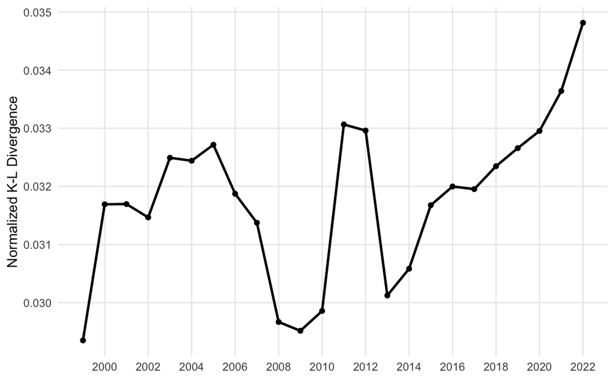

```r
metrics_path_gz <- here::here("data","county_year_quality_metrics.csv.gz")
metrics_path    <- if (file.exists(metrics_path_gz)) metrics_path_gz else here::here("data","county_year_quality_metrics.csv")
dq <- readr::read_csv(metrics_path, show_col_types = FALSE)


.wmean <- function(x, w) {
  w <- ifelse(is.finite(w), w, NA_real_)
  if (all(is.na(w)) || sum(w, na.rm = TRUE) == 0) return(NA_real_)
  stats::weighted.mean(x, w, na.rm = TRUE)
}

ri_ts <- dq %>%
  dplyr::filter(!is.na(year), year >= 1999, year <= 2022, is.finite(RI)) %>%
  dplyr::group_by(year) %>%
  dplyr::summarise(
    wmean_RI  = .wmean(RI, N_garb_g1g2g4g5g6g7),  # weight by targeted garbage bins
    n_ctyyr   = dplyr::n(),
    .groups = "drop"
  )

# Save the underlying series
readr::write_csv(ri_ts, file.path(output_dir, "RI_time_series_1999_2022.csv"))

# Plot (weighted mean only)
p_ri_ts <- ggplot(ri_ts, aes(x = year, y = wmean_RI)) +
  geom_line(linewidth = 1) +
  geom_point(size = 1.7) +
  labs(
    x = NULL, y = "Normalized K-L Divergence"
  ) +
  scale_x_continuous(breaks = seq(2000, 2022, by = 2)) +
  theme_minimal(base_size = 12) +
  theme(
    panel.grid.minor = element_blank(),
    plot.title = element_text(face = "bold")
  )

# Save figure
ggsave(file.path(output_dir, "RI_time_series_1999_2022.png"),
       plot = p_ri_ts, width = 8.5, height = 4.8, dpi = 320)

p_ri_ts
```

Make map of z-scores

```r
# ──────────────────────────────────────────────────────────────
# Cluster z-scores & maps (overdose-unspecified, prop_garbage, RI, Philips)
#   • Robust to: membership duplicates, Philips column names, odd period labels
#   • Outputs:
#       - output/cluster_scores/cluster_zscores_overdose_philips_RI_propgarbage.csv
#       - figures/5yr_avg_stable/z_<metric>_4panel.png  (+ direction_score_4panel.png)
# ──────────────────────────────────────────────────────────────

suppressPackageStartupMessages({
  library(readr);  library(dplyr);  library(stringr); library(tidyr);  library(purrr)
  library(ggplot2); library(sf);     library(tigris);  library(scales); library(here)
})

options(tigris_use_cache = TRUE, tigris_class = "sf", sf_use_s2 = TRUE)

# ------------------------ PATHS ------------------------
data_file       <- here("data",   "county_year_quality_metrics.csv.gz")
membership_file <- here("output", "county_cluster_membership.csv.gz")
philips_file    <- here("output", "cluster_metrics_ucr39_cstd.csv.gz")
out_dir_figs    <- here("figures","5yr_avg_stable")
out_dir_scores  <- here("output", "cluster_scores")
dir.create(out_dir_figs,   recursive = TRUE, showWarnings = FALSE)
dir.create(out_dir_scores, recursive = TRUE, showWarnings = FALSE)

# --------------------- periods & helpers -------------------------
period_levels <- c("1999_2005","2006_2012","2013_2019","2020_2022")
period_of_year <- function(y){
  dplyr::case_when(
    y %in% 1999:2005 ~ "1999_2005",
    y %in% 2006:2012 ~ "2006_2012",
    y %in% 2013:2019 ~ "2013_2019",
    y %in% 2020:2022 ~ "2020_2022",
    TRUE ~ NA_character_
  )
}
standardize_period <- function(p){
  p <- as.character(p)
  out <- ifelse(p %in% period_levels, p, NA_character_)
  bad <- is.na(out) & grepl("^\\d{4}_\\d{4}$", p)
  if (any(bad)) {
    start <- suppressWarnings(as.integer(sub("_(\\d{4})$", "", p[bad])))
    out[bad] <- period_of_year(start)
  }
  out
}
safe_div <- function(num, den) ifelse(is.finite(num) & is.finite(den) & den > 0, num / den, NA_real_)
compute_limits_symmetric <- function(x) {
  x <- x[is.finite(x)]; if (!length(x)) return(c(-1,1))
  L <- as.numeric(stats::quantile(abs(x), 0.98, na.rm = TRUE, names = FALSE))
  if (!is.finite(L) || L == 0) L <- 1
  c(-L, L)
}
sanitize <- function(x) { x %>% str_replace_all("[^A-Za-z0-9]+","_") %>% str_replace_all("^_+|_+$","") %>% tolower() }
pick_col <- function(nms, candidates) { hit <- intersect(candidates, nms); if (length(hit)) hit[1] else NA_character_ }
mode_str <- function(x){ ux <- unique(x); ux[which.max(tabulate(match(x, ux)))] }

# -------------------- projection & geometry helpers -------------------
crs_proj <- 2163
st_shift <- function(sf_obj, shift = c(0, 0)) { st_geometry(sf_obj) <- st_geometry(sf_obj) + shift; sf_obj }
st_scale <- function(sf_obj, scale = 1) { ctr <- st_centroid(st_union(sf_obj)); st_geometry(sf_obj) <- (st_geometry(sf_obj) - ctr) * scale + ctr; sf_obj }
build_counties_2163_resized <- function() {
  us_counties <- tigris::counties(year = 2020, cb = TRUE, class = "sf") |>
    sf::st_transform(crs_proj) |>
    dplyr::select(GEOID, STATEFP, geometry)
  mainland <- us_counties |> dplyr::filter(!STATEFP %in% c("02","15"))
  alaska   <- us_counties |> dplyr::filter(STATEFP == "02") |> st_scale(0.33) |> st_shift(c(1100000, -4700000)) |> sf::st_set_crs(crs_proj)
  hawaii   <- us_counties |> dplyr::filter(STATEFP == "15") |> st_scale(1.00)  |> st_shift(c(5000000, -1100000)) |> sf::st_set_crs(crs_proj)
  dplyr::bind_rows(mainland, alaska, hawaii) |> dplyr::rename(fips = GEOID, statefp = STATEFP) |> sf::st_make_valid()
}
build_states_2163_resized <- function() {
  us_states <- tigris::states(year = 2020, cb = TRUE, class = "sf") |>
    sf::st_transform(crs_proj) |>
    dplyr::select(STATEFP, geometry)
  mainland <- us_states |> dplyr::filter(!STATEFP %in% c("02","15"))
  alaska   <- us_states |> dplyr::filter(STATEFP == "02") |> st_scale(0.33) |> st_shift(c(1100000, -4700000)) |> sf::st_set_crs(crs_proj)
  hawaii   <- us_states |> dplyr::filter(STATEFP == "15") |> st_scale(1.00)  |> st_shift(c(5000000, -1100000)) |> sf::st_set_crs(crs_proj)
  dplyr::bind_rows(mainland, alaska, hawaii) |> sf::st_make_valid()
}

# -------------------- IHME crosswalk (.rda) -------------------
load(here::here("data_raw","ihme_fips.rda"))  # provides ihme_fips
stopifnot(exists("ihme_fips"))
stopifnot(all(c("orig_fips","ihme_fips") %in% names(ihme_fips)))
ihme_map <- ihme_fips %>%
  dplyr::transmute(
    fips        = stringr::str_pad(as.character(orig_fips), 5, pad = "0"),
    county_ihme = stringr::str_pad(as.character(ihme_fips), 5, pad = "0")
  ) %>% dplyr::distinct()

# ------------------------- load membership (dedupe) --------------------
membership_raw <- readr::read_csv(membership_file, show_col_types = FALSE)
membership <-
  if ("county_ihme" %in% names(membership_raw)) {
    membership_raw %>%
      dplyr::mutate(
        county_ihme = stringr::str_pad(as.character(county_ihme), 5, pad = "0"),
        period      = standardize_period(as.character(period)),
        cluster     = as.character(cluster)
      )
  } else if ("fips" %in% names(membership_raw)) {
    membership_raw %>%
      dplyr::mutate(
        fips   = stringr::str_pad(as.character(fips), 5, pad = "0"),
        period = standardize_period(as.character(period)),
        cluster= as.character(cluster)
      ) %>%
      dplyr::left_join(ihme_map, by = "fips") %>%
      dplyr::mutate(county_ihme = dplyr::coalesce(county_ihme, fips)) %>%
      dplyr::select(county_ihme, period, cluster)
  } else stop("membership_file must contain 'county_ihme' or 'fips'.")

# dedupe to one row per county_ihme × period (mode if needed)
membership <- membership %>%
  dplyr::filter(!is.na(period), !is.na(county_ihme), !is.na(cluster)) %>%
  dplyr::distinct(county_ihme, period, cluster)
dups <- membership %>% dplyr::count(county_ihme, period, name="n") %>% dplyr::filter(n > 1)
if (nrow(dups) > 0) message("Resolving ", nrow(dups), " county×period with multiple clusters (using modal cluster).")
membership <- membership %>%
  dplyr::group_by(county_ihme, period) %>%
  dplyr::summarise(cluster = mode_str(cluster), .groups="drop")
```

```r
# --------------------- load county-year data -------------------
stopifnot(file.exists(data_file))
dy0 <- readr::read_csv(data_file, show_col_types = FALSE) %>%
  dplyr::mutate(year = suppressWarnings(as.integer(year)),
                period = period_of_year(year))

if ("county_ihme" %in% names(dy0)) {
  dy <- dy0 %>% dplyr::mutate(county_ihme = stringr::str_pad(as.character(county_ihme), 5, pad = "0"))
} else if ("fips" %in% names(dy0)) {
  dy <- dy0 %>% dplyr::mutate(fips = stringr::str_pad(as.character(fips), 5, pad = "0")) %>%
    dplyr::left_join(ihme_map, by = "fips") %>%
    dplyr::mutate(county_ihme = dplyr::coalesce(county_ihme, fips))
} else stop("data_file must contain 'county_ihme' or 'fips'.")

# --- ensure N_garbage & garb_k exist before checks ---
nms <- names(dy)
col_n_cert <- pick_col(nms, c("n_cert","deaths","total","N"))
col_prop_g <- pick_col(nms, c("foreman_garbage","prop_garbage"))
if (!("N_garbage" %in% nms)) {
  if (!is.na(col_prop_g) && !is.na(col_n_cert)) {
    message("Creating N_garbage = ", col_prop_g, " * ", col_n_cert)
    dy <- dy %>% dplyr::mutate(N_garbage = .data[[col_prop_g]] * .data[[col_n_cert]])
  } else if ("garb_k" %in% nms) {
    message("Using garb_k as N_garbage"); dy <- dy %>% dplyr::mutate(N_garbage = garb_k)
  } else stop("Missing N_garbage and cannot construct it.")
}
if (!("garb_k" %in% nms)) {
  if (!is.na(col_prop_g) && !is.na(col_n_cert)) {
    message("Creating garb_k = ", col_prop_g, " * ", col_n_cert)
    dy <- dy %>% dplyr::mutate(garb_k = .data[[col_prop_g]] * .data[[col_n_cert]])
  } else if ("N_garbage" %in% names(dy)) {
    message("Creating garb_k from N_garbage"); dy <- dy %>% dplyr::mutate(garb_k = N_garbage)
  } else stop("Cannot create garb_k.")
}

# Required vars
need_vars <- c("county_ihme","period","garb_k","n_cert","N_garbage","RI_post_only")
miss <- setdiff(need_vars, names(dy))
if (length(miss)) stop("Missing required columns in data_file: ", paste(miss, collapse=", "))

# ---------------- aggregate county → cluster×period -------------
cluster_core <- dy %>%
  dplyr::select(dplyr::all_of(need_vars)) %>%
  dplyr::filter(!is.na(period)) %>%
  dplyr::inner_join(membership, by = c("county_ihme","period")) %>%
  dplyr::group_by(period, cluster) %>%
  dplyr::summarise(
    sum_garb_k       = sum(garb_k,       na.rm = TRUE),
    sum_n_cert       = sum(n_cert,       na.rm = TRUE),
    sum_N_garbage    = sum(N_garbage,    na.rm = TRUE),
    num_RI_weighted  = sum(n_cert * RI_post_only, na.rm = TRUE),
    prop_garbage      = safe_div(sum_garb_k,       sum_n_cert),
    RI_cluster        = safe_div(num_RI_weighted,  sum_N_garbage),
    .groups = "drop"
  )

# ---------------- bring in Philips (CSTD; tolerant) ------------
stopifnot(file.exists(philips_file))
ph0 <- readr::read_csv(philips_file, show_col_types = FALSE)
# normalize column names to lowercase for matching
names(ph0) <- tolower(names(ph0))

# ensure period
if (!("period" %in% names(ph0))) {
  if ("year" %in% names(ph0)) ph0 <- ph0 %>% dplyr::mutate(period = period_of_year(as.integer(year)))
  else stop("Philips file needs 'period' or 'year'.")
} else {
  ph0 <- ph0 %>% dplyr::mutate(period = standardize_period(period))
}

# normalize IDs to cluster-level
if ("cluster" %in% names(ph0)) {
  ph_norm <- ph0 %>% dplyr::mutate(cluster = as.character(cluster))
} else if ("county_ihme" %in% names(ph0) || "fips" %in% names(ph0)) {
  tmp <- ph0
  if ("fips" %in% names(tmp) && !("county_ihme" %in% names(tmp))) {
    tmp <- tmp %>% dplyr::mutate(fips = stringr::str_pad(as.character(fips), 5, pad="0")) %>%
      dplyr::left_join(ihme_map, by="fips")
  }
  if (!("county_ihme" %in% names(tmp))) stop("Philips file lacks id columns (cluster/county_ihme/fips).")
  ph_norm <- tmp %>%
    dplyr::mutate(county_ihme = stringr::str_pad(as.character(county_ihme), 5, pad="0")) %>%
    dplyr::inner_join(membership, by = c("county_ihme","period"))
} else stop("Philips file must contain 'cluster' or county id (county_ihme/fips).")

# pick cstd & weights robustly
ph_col <- pick_col(names(ph_norm), c("detail_ucod_icd4_cstd","cstd_ucr39","cstd","phillips_detail","philips_detail","cod_cstd","cod_cstd_ucr39"))
if (is.na(ph_col)) stop("Philips source missing CSTD column (tried philips_cstd/cstd_ucr39/cstd/phillips_detail/philips_detail/cod_cstd/...).")
w_col  <- pick_col(names(ph_norm), c("n_cert","deaths","total","n"))

philips_clu <- ph_norm %>%
  dplyr::filter(!is.na(period)) %>%
  dplyr::mutate(cluster = as.character(cluster)) %>%
  dplyr::group_by(period, cluster) %>%
  dplyr::summarise(
    w   = if (!is.na(w_col)) sum(.data[[w_col]], na.rm=TRUE) else NA_real_,
    num = if (!is.na(w_col)) sum(.data[[w_col]] * .data[[ph_col]], na.rm=TRUE) else sum(.data[[ph_col]], na.rm=TRUE),
    den = if (!is.na(w_col)) w else sum(!is.na(.data[[ph_col]])),
    philips_cstd = safe_div(num, den),
    .groups = "drop"
  ) %>%
  dplyr::filter(!is.na(philips_cstd))

# ---------------- merge & Z-scores -----------------------------
metrics_clu <- cluster_core %>%
  dplyr::inner_join(philips_clu, by = c("period","cluster")) %>%
  dplyr::filter(period %in% period_levels) %>%
  dplyr::arrange(period, cluster) %>%
  dplyr::mutate(cluster = as.character(cluster), period = as.character(period))

score_vars  <- c("philips_cstd","RI_cluster","prop_garbage")
global_means <- vapply(score_vars, function(v) mean(metrics_clu[[v]], na.rm = TRUE), numeric(1))
global_sds   <- vapply(score_vars, function(v)  sd(metrics_clu[[v]], na.rm = TRUE), numeric(1))
global_sds[!is.finite(global_sds) | global_sds == 0] <- NA_real_

z_tbl <- metrics_clu %>%
  dplyr::mutate(dplyr::across(
    dplyr::all_of(score_vars),
    \(x, nm=cur_column()) if (is.na(global_sds[[nm]])) NA_real_ else (x - global_means[[nm]]) / global_sds[[nm]],
    .names = "z_{.col}"
  )) %>%
  # Flip signs: higher z = better (less garbage / fewer unspecified overdoses)
  dplyr::mutate(
    z_prop_garbage      = -z_prop_garbage,
  ) %>%
  dplyr::mutate(
    direction_score = rowMeans(dplyr::across(starts_with("z_")), na.rm = TRUE)
  ) %>%
  dplyr::arrange(period, cluster)
```

```r
readr::write_csv(z_tbl, file.path(out_dir_scores, "cluster_zscores_overdose_philips_RI_propgarbage.csv"))

# ---------------- geometry & cluster polygons -----------------
counties_tf <- build_counties_2163_resized()
states_tf   <- build_states_2163_resized()
counties_aug <- counties_tf %>% dplyr::left_join(ihme_map, by = "fips") %>% dplyr::mutate(county_ihme = dplyr::coalesce(county_ihme, fips))

build_cluster_sf <- function(period_key, membership_df, counties_sf_aug) {
  mm <- membership_df %>% dplyr::filter(.data$period == period_key) %>% dplyr::transmute(county_ihme = as.character(county_ihme), cluster = as.character(cluster)) %>% dplyr::distinct()
  if (!nrow(mm)) stop("No membership rows for period: ", period_key)
  counties_sf_aug %>%
    dplyr::inner_join(mm, by = "county_ihme") %>%
    dplyr::group_by(cluster) %>%
    dplyr::summarise(geometry = sf::st_union(geometry), .groups = "drop") %>%
    sf::st_make_valid()
}

# ---------------- 4-panel maps of Z-scores --------------------
make_faceted_map <- function(stacked_sf, fill_col, lims, states_sf) {
  ggplot2::ggplot() +
    geom_sf(data = stacked_sf, aes(fill = .data[[fill_col]]), colour = NA) +
    geom_sf(data = states_sf, fill = NA, colour = "white", linewidth = 0.3) +
    scale_fill_distiller(palette = "RdBu", direction = 1, limits = lims, oob = scales::squish, na.value = "grey90") +
    coord_sf(xlim = c(-2500000, 2500000), ylim = c(-2200000, 730000), expand = FALSE) +
    labs(fill = NULL) + facet_wrap(~ period, ncol = 2) + theme_void() +
    theme(strip.text = element_text(size = 12, face = "bold"), legend.text = element_text(size = 9), plot.title = element_blank())
}

to_map <- c("z_RI_cluster","z_prop_garbage","z_philips_cstd","direction_score")

for (mcol in to_map) {
  message("Assembling 4-panel for metric: ", mcol)
  stacked_sf <- purrr::map_dfr(period_levels, function(win){
    cl_sf <- build_cluster_sf(win, membership, counties_aug)
    dat   <- z_tbl %>% dplyr::filter(period==win) %>% dplyr::select(cluster, !!rlang::sym(mcol)) %>% dplyr::rename(value = !!rlang::sym(mcol))
    out   <- cl_sf %>% dplyr::left_join(dat, by="cluster"); out$period <- win; out
  }) %>% dplyr::mutate(period=factor(period, levels=period_levels))

  vals <- stacked_sf$value[is.finite(stacked_sf$value)]
  if (!length(vals) || length(unique(vals))==1) { message("  Skipping ", mcol, " (no variance)"); next }

  lims_sym <- compute_limits_symmetric(vals)  # symmetric for z-scores (centered at 0)
  p <- make_faceted_map(stacked_sf, "value", lims_sym, states_tf)

  base <- if (mcol == "direction_score") "direction_score" else sanitize(mcol)
  ggsave(file.path(out_dir_figs, paste0(base, "_4panel.png")), p, width=10, height=7.5, dpi=320)
}
```

[output not shown]

```r
message("✓ Done. Z-score CSV in: ", out_dir_scores, "  |  maps in: ", out_dir_figs)
```

```
G3;✓ Done. Z-score CSV in: /Users/amymann/Documents/Data Quality Project/DataQuality/output/cluster_scores  |  maps in: /Users/amymann/Documents/Data Quality Project/DataQuality/figures/5yr_avg_stable
g
```

Make new aggregate data quality index map with box plot (you must run previous chunk first)

```r
# Fixed: Two maps (1999–2005, 2020–2022) + county-by-state boxplot
suppressPackageStartupMessages({
  library(dplyr); library(stringr); library(sf); library(ggplot2)
  library(patchwork); library(scales); library(tigris)
})

# --- user-configurable ---
metric_to_plot <- "direction_score"
out_dir_figs <- if (exists("out_dir_figs")) out_dir_figs else "figures/5yr_avg_stable"
dir.create(out_dir_figs, recursive = TRUE, showWarnings = FALSE)

metric_label <- dplyr::case_when(
  metric_to_plot == "direction_score"      ~ "Aggregate data quality index (z)",
  metric_to_plot == "z_prop_garbage"       ~ "Proportion garbage (z, higher is better)",
  metric_to_plot == "z_philips_cstd"       ~ "Philips CSTD (z, higher is better)",
  metric_to_plot == "z_RI_cluster"         ~ "RI (z, higher is better)",
  TRUE ~ metric_to_plot
)

# --- Normalize IDs (robust) ---
# membership: ensure county_ihme exists & normalised
if (!"county_ihme" %in% names(membership)) {
  if ("fips" %in% names(membership)) {
    membership <- membership %>% mutate(county_ihme = str_pad(as.character(fips), 5, pad = "0"))
  } else stop("membership lacks county_ihme and fips; please create county_ihme first.")
} else {
  membership <- membership %>%
    mutate(county_ihme = str_pad(str_replace_all(as.character(county_ihme), "[^0-9]", ""), 5, pad = "0"))
}

# -------------------- IHME crosswalk (.rda) -------------------
load(here::here("data_raw","ihme_fips.rda"))  # provides ihme_fips
stopifnot(exists("ihme_fips"))
stopifnot(all(c("orig_fips","ihme_fips") %in% names(ihme_fips)))
ihme_map <- ihme_fips %>%
  dplyr::transmute(
    fips        = stringr::str_pad(as.character(orig_fips), 5, pad = "0"),
    county_ihme = stringr::str_pad(as.character(ihme_fips), 5, pad = "0")
  ) %>% dplyr::distinct()


# ---------------- geometry & cluster polygons -----------------
counties_tf <- build_counties_2163_resized()
states_tf   <- build_states_2163_resized()
counties_aug <- counties_tf %>% dplyr::left_join(ihme_map, by = "fips") %>% dplyr::mutate(county_ihme = dplyr::coalesce(county_ihme, fips))


# counties_lite from counties_aug (guarantee county_ihme + statefp)
counties_lite <- counties_aug %>% st_drop_geometry() %>% mutate(across(everything(), ~ if (is.factor(.)) as.character(.) else .))
if (!"county_ihme" %in% names(counties_lite)) {
  cand <- intersect(c("county_ihme","GEOID","geoid","fips","FIPS","COUNTYFP"), names(counties_lite))
  if (length(cand)) names(counties_lite)[which(names(counties_lite) == cand[1])] <- "county_ihme"
}
counties_lite <- counties_lite %>%
  mutate(county_ihme = str_pad(str_replace_all(as.character(county_ihme), "[^0-9]", ""), 5, pad = "0"))

# ensure statefp exists, derive from county_ihme if needed
if (!"statefp" %in% names(counties_lite)) {
  if ("STATEFP" %in% names(counties_lite)) {
    counties_lite <- counties_lite %>% rename(statefp = STATEFP)
  } else {
    counties_lite <- counties_lite %>% mutate(statefp = substr(county_ihme, 1, 2))
  }
}
counties_lite <- counties_lite %>% mutate(statefp = str_pad(str_replace_all(as.character(statefp), "[^0-9]", ""), 2, pad = "0"))

# states info (safe)
states_info <- tigris::states(year = 2020, cb = TRUE, class = "sf") %>%
  sf::st_drop_geometry() %>%
  mutate(STATEFP = str_pad(as.character(STATEFP), 2, pad = "0")) %>%
  dplyr::select(STATEFP, STUSPS) %>%
  dplyr::rename(statefp = STATEFP, state = STUSPS)

# --- helper: make single period map (safe) ---
make_single_map <- function(period_key, mcol, lims, states_sf, membership_df, counties_sf_aug) {
  # build cluster polygons for that period using your build_cluster_sf function
  cl_sf <- build_cluster_sf(period_key, membership_df, counties_sf_aug)
  dat <- z_tbl %>%
    filter(period == period_key) %>%
    select(cluster, value = !!rlang::sym(mcol))
  map_sf <- cl_sf %>% left_join(dat, by = "cluster")
  ggplot() +
    geom_sf(data = map_sf, aes(fill = value), colour = NA) +
    geom_sf(data = states_sf, fill = NA, colour = "white", linewidth = 0.3) +
    scale_fill_distiller(palette = "RdBu", direction = 1,
                         limits = lims, oob = scales::squish, na.value = "grey90") +
    coord_sf(xlim = c(-2500000, 2500000), ylim = c(-2200000, 730000), expand = FALSE) +
    labs(title = gsub("_", "–", period_key), fill = NULL) +
    theme_void(base_size = 11) +
    theme(plot.title = element_text(hjust = 0.5, face = "bold"))
}

# --- build map limits across the two periods ---
periods_two <- c("1999_2005","2020_2022")
map_vals <- purrr::map_dfr(periods_two, function(win) {
  cl_sf <- build_cluster_sf(win, membership, counties_aug)
  dat <- z_tbl %>% filter(period == win) %>% select(cluster, value = !!rlang::sym(metric_to_plot))
  cl_sf %>% left_join(dat, by="cluster") %>% transmute(value)
})
```

[output not shown]

```r
lims_sym <- compute_limits_symmetric(map_vals$value)

# --- create maps ---
pA <- make_single_map("1999_2005", metric_to_plot, lims_sym, states_tf, membership, counties_aug)
```

[output not shown]

```r
pB <- make_single_map("2020_2022", metric_to_plot, lims_sym, states_tf, membership, counties_aug)
```

[output not shown]

```r
# --- build county-level dataframe safely ---
build_county_values_safe <- function(per, membership_df = membership, z_tbl_df = z_tbl, counties_df = counties_lite, states_df = states_info) {
  mm <- membership_df %>% filter(period == per) %>% distinct(county_ihme, cluster, .keep_all = TRUE)
  zv <- z_tbl_df %>% filter(period == per) %>% select(cluster, value = !!rlang::sym(metric_to_plot))
  joined <- mm %>% left_join(zv, by = "cluster")
  # ensure counties_df has county_ihme and statefp
  if (!"county_ihme" %in% names(counties_df)) stop("counties_df must have county_ihme")
  if (!"statefp" %in% names(counties_df)) counties_df <- counties_df %>% mutate(statefp = substr(county_ihme,1,2))
  joined2 <- joined %>% left_join(counties_df %>% select(county_ihme, statefp), by = "county_ihme")
  joined3 <- joined2 %>% left_join(states_df, by = "statefp") %>%
    mutate(period = per)
  # keep only rows with a state label and finite value
  res <- joined3 %>% filter(!is.na(state), is.finite(value)) %>% select(state, county_ihme, period, value)
  return(res)
}

bx_df <- bind_rows(build_county_values_safe("1999_2005"),
                   build_county_values_safe("2020_2022"))

# --- prepare boxplot df: rank states by 2020-2022 median, drop territories ---
state_order <- bx_df %>%
  filter(period == "2020_2022") %>%
  group_by(state) %>%
  summarise(med = median(value, na.rm = TRUE), .groups = "drop") %>%
  arrange(desc(med)) %>% pull(state)

territories <- c("PR","GU","VI","AS","MP")
bx_df <- bx_df %>% filter(!state %in% territories)

bx_df <- bx_df %>%
  mutate(
    state = factor(state, levels = state_order),
    period = factor(period, levels = c("1999_2005","2020_2022"),
                    labels = c("1999–2005","2020–2022"))
  )

# --- boxplot (visual choices can be adjusted) ---
ylims_box <- c(-2, 2)
pC <- ggplot(bx_df, aes(x = state, y = value, fill = period)) +
  geom_hline(yintercept = 0, linetype = 3, linewidth = 0.3) +
  geom_boxplot(width = 0.7, outlier.alpha = 0.4,
               position = position_dodge2(width = 0.75, preserve = "single")) +
  coord_cartesian(ylim = ylims_box) +
  scale_fill_manual(values = c("#94bedf","#f2c879")) +
  labs(x = "States (ranked by declining median county-level 2020-2022 aggregate data quality index)",
       y = metric_label) +
  theme_bw(base_size = 10) +
  theme(
    legend.position = "top",
    axis.text.x = element_text(angle = 90, vjust = 0.5, hjust = 1),
    panel.grid.minor = element_blank()
  )

# --- combine and save ---
combined <- (pA | pB) / pC + plot_layout(guides = "collect") + plot_annotation(tag_levels = "A")
```

|  | t | l | b | r |
| --- | --- | --- | --- | --- |
| 1: | 1 | 1 | 1 | 1 |
| 2: | 1 | 2 | 1 | 2 |

```r
base <- if (metric_to_plot == "direction_score") "direction_score" else gsub("[^A-Za-z0-9_-]", "_", metric_to_plot)
outfile <- file.path(out_dir_figs, paste0("two_maps_box_", base, ".png"))
ggsave(outfile, combined, width = 11, height = 8.5, dpi = 320)
cat("Wrote:", outfile, "\n")
```

```
Wrote: /Users/amymann/Documents/Data Quality Project/DataQuality/figures/5yr_avg_stable/two_maps_box_direction_score.png
```

```r
# -------------------- period means + 95% CI + IQR (county-level; robust to labels) --------------------

# Helper: normalize different period label formats to canonical keys
normalize_period_key <- function(p) {
  p_chr <- as.character(p)
  # convert en/em dashes to hyphen, remove spaces
  p_chr <- gsub("\u2013|\u2014", "-", p_chr)    # en/em dash -> hyphen
  p_chr <- gsub("\\s+", "", p_chr)             # remove spaces
  sapply(p_chr, function(x) {
    if (grepl("^1999[_\\-]?2005$", x)) return("1999_2005")
    if (grepl("^2013[_\\-]?2019$", x)) return("2013_2019")
    if (grepl("^2020[_\\-]?2022$", x)) return("2020_2022")
    # if already canonical or unknown, return as-is
    return(x)
  }, USE.NAMES = FALSE)
}

# Ensure bx_df exists
if (!exists("bx_df")) stop("bx_df not found. Run the map/boxplot chunk first.")

# Add canonical period_key column (preserve original 'period' for printing)
bx_df <- bx_df %>% mutate(period_key = normalize_period_key(period))

# If 2013_2019 missing, build it and append
if (!"2013_2019" %in% unique(bx_df$period_key)) {
  message("2013_2019 not found in bx_df — building and appending county-level values for 2013_2019.")
  bx_2013_2019 <- build_county_values_safe("2013_2019")
  bx_2013_2019 <- bx_2013_2019 %>% mutate(period_key = normalize_period_key(period))
  bx_df <- bind_rows(bx_df, bx_2013_2019)
}
```

```
G3;2013_2019 not found in bx_df — building and appending county-level values for 2013_2019.
g
```

```r
# Keep only canonical three periods and finite values
target_periods <- c("1999_2005", "2013_2019", "2020_2022")
bx_df2 <- bx_df %>% filter(period_key %in% target_periods & is.finite(value))

# safe IQR helper
iqr_safe <- function(x) {
  if (sum(is.finite(x)) < 2) return(c(NA_real_, NA_real_))
  stats::quantile(x, probs = c(0.25, 0.75), na.rm = TRUE, names = FALSE)
}

# Summarise: n, mean, sd, se, t CI, q1, q3, iqr
summary_ci_tbl <- bx_df2 %>%
  dplyr::group_by(period_key) %>%
  dplyr::summarise(
    n       = dplyr::n(),
    mean    = mean(value, na.rm = TRUE),
    sd      = sd(value, na.rm = TRUE),
    se      = sd / sqrt(n),
    t_975   = ifelse(n > 1, stats::qt(0.975, df = n - 1), NA_real_),
    ci_low  = ifelse(n > 1, mean - t_975 * se, NA_real_),
    ci_high = ifelse(n > 1, mean + t_975 * se, NA_real_),
    q1      = iqr_safe(value)[1],
    q3      = iqr_safe(value)[2],
    iqr     = q3 - q1,
    .groups = "drop"
  ) %>%
  dplyr::arrange(factor(period_key, levels = target_periods))

# pretty label
pretty_label <- function(key) {
  switch(as.character(key),
         "1999_2005" = "1999–2005",
         "2013_2019" = "2013–2019",
         "2020_2022" = "2020–2022",
         as.character(key))
}

# Print formatted summary to console
cat("\n---- Aggregate index (county-level) — mean ± 95% CI; SD; IQR ----\n")
```

```
---- Aggregate index (county-level) — mean ± 95% CI; SD; IQR ----
```

```r
cat(" Period         n     Mean     SD     95% CI [low, high]      Q1     Q3    IQR\n")
```

```
 Period         n     Mean     SD     95% CI [low, high]      Q1     Q3    IQR
```

```r
cat("-------------------------------------------------------------------------------\n")
for (i in seq_len(nrow(summary_ci_tbl))) {
  row <- summary_ci_tbl[i, ]
  lab <- pretty_label(row$period_key)
  cat(sprintf("%-13s %5d  %7.3f  %6.3f   [%7.3f, %7.3f]   %6.3f  %6.3f  %6.3f\n",
              lab, row$n, row$mean, row$sd, row$ci_low, row$ci_high, row$q1, row$q3, row$iqr))
}
```

```
1999–2005    3136   -0.417   0.610   [ -0.438,  -0.396]   -0.839  -0.044   0.795
2013–2019    3139    0.168   0.619   [  0.146,   0.190]   -0.202   0.532   0.735
2020–2022    3139    0.097   0.660   [  0.074,   0.120]   -0.323   0.512   0.835
```

```r
cat("-------------------------------------------------------------------------------\n\n")
# Save CSV
summary_outfile2 <- file.path(out_dir_figs, paste0("two_maps_box_", base, "_mean_CI_IQR_by_period.csv"))
readr::write_csv(summary_ci_tbl, summary_outfile2)
cat("Saved summary CSV: ", summary_outfile2, "\n")
```

```
Saved summary CSV:  /Users/amymann/Documents/Data Quality Project/DataQuality/figures/5yr_avg_stable/two_maps_box_direction_score_mean_CI_IQR_by_period.csv
```

NEW: Correlation time series figure

```r
# ──────────────────────────────────────────────────────────────
# Re-create inputs for correlation time series (unchanged from your snippet)
# ... (keep the top part of your original script that reads cy, income_all, ph_pc, rep_lu)
# For brevity here I assume you've already run the input-loading section from your original message
# and we resume at the Correlation time series section.
# ──────────────────────────────────────────────────────────────

suppressPackageStartupMessages({
  library(dplyr); library(readr); library(stringr); library(tidyr)
  library(ggplot2); library(patchwork); library(scales); library(here); library(purrr)
})

dir.create(here("figures"), recursive = TRUE, showWarnings = FALSE)

# ---------- guards: insist on separate inputs ----------
stopifnot(exists("cy"), is.data.frame(cy))
stopifnot(exists("income_all"), is.data.frame(income_all))
stopifnot(exists("ph_pc"), is.data.frame(ph_pc))
stopifnot(exists("rep_lu"), is.data.frame(rep_lu))

# ---------- helper utils ----------
std_fips <- function(x) stringr::str_pad(as.character(x), 5, pad = "0")
`%||%` <- function(a,b) if (!is.null(a) && length(a) && !all(is.na(a))) a else b
find_col <- function(df, patterns) {
  for (pat in patterns) {
    hit <- names(df)[grepl(pat, names(df), ignore.case = TRUE)]
    if (length(hit)) return(hit[1])
  }
  NA_character_
}
safe_cor <- function(x, y) {
  ok <- is.finite(x) & is.finite(y)
  if (sum(ok) < 3) return(NA_real_)
  cor(x[ok], y[ok], method = "pearson")
}
period_levels <- c("1999_2005","2006_2012","2013_2019","2020_2022")
period_midyrs <- c(2002L, 2009L, 2016L, 2021L)
period_map <- tibble(period = period_levels, year = period_midyrs)

# ---------- normalize core inputs ----------
cy <- cy %>%
  mutate(county_ihme = std_fips(county_ihme),
         year = suppressWarnings(as.integer(year))) %>%
  filter(year >= 1999, year <= 2022, county_ihme != "00000")

# prop_garbage + RI columns in cy
prop_garbage_col <- find_col(
  cy, c("prop_garbage")
)
ri_col <- c("RI_post_only")
ri_col <- ri_col[ri_col %in% names(cy)][1] %||% NA_character_
stopifnot(!is.na(prop_garbage_col), !is.na(ri_col))

cy_metrics <- cy %>%
  transmute(county_ihme, year,
            prop_garbage = suppressWarnings(as.numeric(.data[[prop_garbage_col]])),
            ri           = suppressWarnings(as.numeric(.data[[ri_col]])))

# ---------- build per-county STABLE predictors from separate inputs ----------
income_pred <- income_all %>%
  transmute(county_ihme = std_fips(county_ihme),
            avg_income = suppressWarnings(as.numeric(
              .data[[find_col(., c("^avg[_ ]?income$","median[_ ]?household[_ ]?income","median[_ ]?income","b19013_001"))]]
            ))) %>%
  filter(is.finite(avg_income)) %>%
  group_by(county_ihme) %>%
  summarise(income_med = median(avg_income, na.rm = TRUE), .groups = "drop")

ph_val_col <- find_col(ph_pc, c("^ph[_ ]?pc$","ph[_ ]?per[_ ]?capita","per[_ ]?capita"))
ph_pred <- ph_pc %>%
  transmute(county_ihme = std_fips(county_ihme),
            ph_pc_val  = suppressWarnings(as.numeric(.data[[ph_val_col]]))) %>%
  filter(is.finite(ph_pc_val)) %>%
  group_by(county_ihme) %>%
  summarise(ph_pc_med = median(ph_pc_val, na.rm = TRUE), .groups = "drop")

# ---------- MODIFY: reporting type -> binary 1/0 for ME vs Coroner, exclude Mixed/Other ----------
# 1 = Medical Examiner, 0 = Coroner, Mixed/Other -> NA (excluded)
rep_pred <- rep_lu %>%
  transmute(county_ihme = std_fips(county_ihme),
            reporting_raw = tolower(trimws(as.character(reporting_type)))) %>%
  mutate(
    reporting_num = case_when(
      grepl("medical|\\bme\\b|examiner", reporting_raw) ~ 1L,
      grepl("coroner", reporting_raw)                 ~ 0L,
      TRUE                                            ~ NA_integer_
    )
  ) %>%
  select(county_ihme, reporting_num)

# ---------- DETAIL (ICD-4) at 4 periods → assign to counties via membership ----------
detail_path <- here("output","cluster_metrics_ucr39_cstd.csv.gz")
membership_path <- here("output","county_cluster_membership.csv.gz")
stopifnot(file.exists(detail_path), file.exists(membership_path))

detail_cluster <- readr::read_csv(detail_path, show_col_types = FALSE)
mem <- readr::read_csv(membership_path, show_col_types = FALSE) %>%
  transmute(county_ihme = std_fips(fips %||% county_ihme %||% GEOID %||% FIPS),
            period = as.character(period),
            cluster = as.character(cluster)) %>%
  distinct()

detail_col <- "detail_ucod_icd4_cstd"
stopifnot(!is.na(detail_col))

detail_cnty_midyears <- detail_cluster %>%
  transmute(period = as.character(period),
            cluster = as.character(cluster),
            detail_icd4 = suppressWarnings(as.numeric(.data[[detail_col]]))) %>%
  inner_join(mem, by = c("cluster","period")) %>%
  inner_join(period_map, by = "period") %>%
  transmute(county_ihme, year, detail_icd4)

# ---------- AGGREGATE INDEX at those 4 midyears ----------
z <- function(v){ m <- mean(v, na.rm = TRUE); s <- sd(v, na.rm = TRUE); if (!is.finite(s) || s==0) return(rep(0,length(v))); (v-m)/s }
agg_df <- cy_metrics %>%
  semi_join(period_map, by = "year") %>%
  left_join(detail_cnty_midyears, by = c("county_ihme","year")) %>%
  group_by(year) %>%
  mutate(agg_index = z(-prop_garbage) + z(detail_icd4) + z(ri)) %>%
  ungroup() %>%
  select(county_ihme, year, agg_index)

# ---------- attach predictors to each metric frame ----------
with_preds <- function(df) {
  df %>%
    left_join(income_pred, by = "county_ihme") %>%
    left_join(ph_pred,     by = "county_ihme") %>%
    left_join(rep_pred,    by = "county_ihme")
}

cy_pg  <- with_preds(cy_metrics %>% select(county_ihme, year, value = prop_garbage))
cy_ri  <- with_preds(cy_metrics %>% select(county_ihme, year, value = ri))
cy_det <- with_preds(detail_cnty_midyears %>% select(county_ihme, year, value = detail_icd4))
cy_agg <- with_preds(agg_df %>% select(county_ihme, year, value = agg_index))

# ---------- compute yearly correlations across counties ----------
compute_yearly_corrs <- function(df, label) {
  df %>%
    group_by(year) %>%
    summarise(
      `Income`                        = safe_cor(value, income_med),
      `PH spend (pc)`                 = safe_cor(value, ph_pc_med),
      # use binary reporting_num: 1 = ME, 0 = Coroner; Mixed/Other are NA and excluded
      `Reporting (ME=1, Coroner=0)`   = safe_cor(value, reporting_num),
      .groups = "drop"
    ) %>%
    pivot_longer(cols = -year, names_to = "predictor", values_to = "corr") %>%
    mutate(metric = label)
}

ts_pg  <- compute_yearly_corrs(cy_pg,  "Proportion garbage")
ts_ri  <- compute_yearly_corrs(cy_ri,  "RI")
ts_det <- compute_yearly_corrs(cy_det, "Level of detail") %>% semi_join(period_map, by = "year")
ts_agg <- compute_yearly_corrs(cy_agg, "Aggregate index") %>% semi_join(period_map, by = "year")

# ---------- plotting ----------
y_lim_pg  <- c(-0.35, 0.35)  # Panel 1: prop_garbage vs predictors
y_lim_ri  <- c(-0.35, 0.35)  # Panel 2: RI vs predictors
y_lim_det <- c(-0.35, 0.35)  # Panel 3: Detail vs predictors (4 points)
y_lim_agg <- c(-0.35, 0.35)  # Panel 4: Aggregate index vs predictors (4 points)

plot_ts <- function(df, title, show_points = TRUE, y_lim = c(-0.35, 0.35)) {
  df <- df %>% dplyr::filter(!is.na(corr))
  ggplot(df, aes(x = year, y = corr, colour = predictor)) +
    geom_hline(yintercept = 0, linewidth = 0.4, linetype = "dashed") +
    geom_line(linewidth = 1) +
    { if (show_points) geom_point(size = 1.8) else NULL } +
    scale_x_continuous(breaks = seq(2000, 2022, 2)) +
    coord_cartesian(ylim = y_lim) +
    labs(title = title, x = NULL, y = "Pearson correlation", colour = NULL) +
    theme_bw(base_size = 11) +
    theme(legend.position = "bottom",
          plot.title = element_text(face = "bold"))
}

g1 <- plot_ts(ts_pg,  "Proportion garbage", TRUE, y_lim_pg)
g2 <- plot_ts(ts_ri,  "RI ",            TRUE, y_lim_ri)
g3 <- plot_ts(ts_det, "Level of detail", TRUE, y_lim_det)
g4 <- plot_ts(ts_agg, "Aggregate data quality index vs income / PH spend / reporting (ME=1, Coroner=0)", TRUE, y_lim_agg)

fig <- (g1 | g2) / (g3 | g4) + patchwork::plot_layout(guides = "collect") &
  theme(legend.position = "bottom")
```

[output not shown]

```r
# ---------- NEW: summary of average correlations (across years) ----------
summary_df <- bind_rows(ts_pg, ts_ri, ts_det, ts_agg) %>%
  group_by(metric, predictor) %>%
  summarise(
    mean_corr = mean(corr, na.rm = TRUE),
    n_years   = sum(!is.na(corr)),
    .groups = "drop"
  ) %>%
  arrange(metric, predictor) %>%
  mutate(mean_corr = round(mean_corr, 3))

# print nicely in console
message("\n# Average Pearson correlations (mean across years) — metric × predictor\n")
```

```
G3;
# Average Pearson correlations (mean across years) — metric × predictor

g
```

```r
print(summary_df)
```

| metric | predictor | mean_corr | n_years |
| --- | --- | --- | --- |
| Aggregate index | Income | 0.309 | 4 |
| Aggregate index | PH spend (pc) | 0.115 | 4 |
| Aggregate index | Reporting (ME=1, Coroner=0) | 0.294 | 4 |
| Level of detail | Income | 0.212 | 4 |
| Level of detail | PH spend (pc) | 0.044 | 4 |
| Level of detail | Reporting (ME=1, Coroner=0) | 0.216 | 4 |
| Proportion garbage | Income | -0.204 | 24 |
| Proportion garbage | PH spend (pc) | -0.095 | 24 |
| Proportion garbage | Reporting (ME=1, Coroner=0) | -0.249 | 24 |
| RI | Income | 0.116 | 24 |

[output cut: 2 more lines]

```r
# also pivot to wide for easy viewing/saving
summary_wide <- summary_df %>%
  select(metric, predictor, mean_corr) %>%
  pivot_wider(names_from = predictor, values_from = mean_corr)

# write CSV for record
summary_outfile <- here::here("figures","correlations_summary.csv")
readr::write_csv(summary_wide, summary_outfile)
message("Wrote summary CSV: ", summary_outfile, "\n")
```

```
G3;Wrote summary CSV: /Users/amymann/Documents/Data Quality Project/DataQuality/figures/correlations_summary.csv

g
```

```r
# ---------- save figure ----------
outfile <- here::here("figures","correlations_four_panel.png")
ggsave(outfile, fig, width = 13, height = 8.5, dpi = 320)
message("Wrote: ", outfile)


ts_all <- bind_rows(ts_pg, ts_ri, ts_det, ts_agg)

# Long format: one row per metric × year × predictor
ts_all_out_long <- ts_all %>%
  arrange(metric, year, predictor)

ts_all_long_file <- here::here("figures", "correlations_time_series_long.csv")
readr::write_csv(ts_all_out_long, ts_all_long_file)
message("Wrote time-series (long) CSV: ", ts_all_long_file)

# Wide format: one row per metric × year, predictors as columns
ts_all_out_wide <- ts_all %>%
  select(metric, year, predictor, corr) %>%
  tidyr::pivot_wider(
    names_from  = predictor,
    values_from = corr
  ) %>%
  arrange(metric, year)

ts_all_wide_file <- here::here("figures", "correlations_time_series_wide.csv")
readr::write_csv(ts_all_out_wide, ts_all_wide_file)
message("Wrote time-series (wide) CSV: ", ts_all_wide_file)
```

Make new level of detail maps with box plots

```r
# ──────────────────────────────────────────────────────────────
# Two maps (1999–2005, 2020–2022) + box plot
# COD standardized diversity — UCOD 4-digit (detail_ucod_icd4_cstd)
#   • Clustering EXACTLY like your COD script: membership (fips, cluster, period)
#   • AK/HI resized & shifted (same helpers as your script)
#   • Viridis "D"; common limits across the two periods from 2–98% quantiles
#   • NO imputation/backup fills — if a cluster-period is missing, it will be NA
#   • Saves → figures/5yr_avg_stable/two_maps_box_detail_ucod_icd4_cstd.png
# ──────────────────────────────────────────────────────────────

suppressPackageStartupMessages({
  library(readr);  library(dplyr);  library(stringr); library(tidyr);  library(tibble)
  library(ggplot2); library(sf);     library(tigris);  library(scales); library(here)
  library(purrr);   library(patchwork)
})

options(tigris_use_cache = TRUE, tigris_class = "sf", sf_use_s2 = TRUE)

# ------------------------ paths -------------------------------
metrics_file    <- here("output", "cluster_metrics_ucr39_cstd.csv.gz")
membership_file <- here("output", "county_cluster_membership.csv.gz")
out_dir_base    <- here("figures", "5yr_avg_stable")
dir.create(out_dir_base, recursive = TRUE, showWarnings = FALSE)

# -------------------- projection ------------------------------
crs_proj <- 2163

# --------------------- stable periods -------------------------
# Use the same labels as your working scripts
period_levels <- c("1999_2005","2006_2012","2013_2019","2020_2022")
periods_two   <- c("1999_2005","2020_2022")
territories   <- c("PR","GU","VI","AS","MP")

# ------------------------ helpers -----------------------------
sanitize <- function(x) {
  x %>% str_replace_all("[^A-Za-z0-9]+", "_") %>%
    str_replace_all("^_+|_+$", "") %>% tolower()
}

st_shift <- function(sf_obj, shift = c(0, 0)) { st_geometry(sf_obj) <- st_geometry(sf_obj) + shift; sf_obj }
st_scale <- function(sf_obj, scale = 1) {
  centroid <- st_centroid(st_union(sf_obj))
  st_geometry(sf_obj) <- (st_geometry(sf_obj) - centroid) * scale + centroid
  sf_obj
}

build_counties_2163_resized <- function() {
  us_counties <- tigris::counties(year = 2020, cb = TRUE, class = "sf") |>
    sf::st_transform(crs_proj) |>
    dplyr::select(GEOID, STATEFP, geometry)

  mainland <- us_counties |> dplyr::filter(!STATEFP %in% c("02","15"))
  alaska   <- us_counties |> dplyr::filter(STATEFP == "02") |>
                st_scale(0.33) |>
                st_shift(c(1100000, -4700000)) |>
                sf::st_set_crs(crs_proj)
  hawaii   <- us_counties |> dplyr::filter(STATEFP == "15") |>
                st_scale(1)  |>
                st_shift(c(5000000, -1100000)) |>
                sf::st_set_crs(crs_proj)

  dplyr::bind_rows(mainland, alaska, hawaii) |>
    dplyr::rename(fips = GEOID, statefp = STATEFP) |>
    sf::st_make_valid()
}

build_states_2163_resized <- function() {
  us_states <- tigris::states(year = 2020, cb = TRUE, class = "sf") |>
    sf::st_transform(crs_proj) |>
    dplyr::select(STATEFP, geometry)

  mainland <- us_states |> dplyr::filter(!STATEFP %in% c("02","15"))
  alaska   <- us_states |> dplyr::filter(STATEFP == "02") |>
                st_scale(0.33) |>
                st_shift(c(1100000, -4700000)) |>
                sf::st_set_crs(crs_proj)
  hawaii   <- us_states |> dplyr::filter(STATEFP == "15") |>
                st_scale(1)  |>
                st_shift(c(5000000, -1100000)) |>
                sf::st_set_crs(crs_proj)

  dplyr::bind_rows(mainland, alaska, hawaii) |>
    sf::st_make_valid()
}

# Build cluster polygons exactly like your COD script: per-period membership → union by cluster
build_cluster_sf <- function(period_key, membership_df, counties_sf) {
  mm <- membership_df %>%
    dplyr::filter(.data$period == period_key) %>%
    dplyr::transmute(fips = stringr::str_pad(as.character(fips), 5, pad = "0"),
                     cluster = as.character(cluster)) %>%
    dplyr::distinct()
  if (!nrow(mm)) stop("No membership rows for period: ", period_key)

  counties_sf %>%
    dplyr::inner_join(mm, by = "fips") %>%
    dplyr::group_by(cluster) %>%
    dplyr::summarise(geometry = sf::st_union(geometry), .groups = "drop") %>%
    sf::st_make_valid()
}

# ------------------------- load data --------------------------
message("Reading metrics: ", metrics_file)
```

```
G3;Reading metrics: /Users/amymann/Documents/Data Quality Project/DataQuality/output/cluster_metrics_ucr39_cstd.csv.gz
g
```

```r
metrics <- readr::read_csv(metrics_file, show_col_types = FALSE) %>%
  dplyr::mutate(cluster = as.character(cluster), period = as.character(period))

message("Reading membership: ", membership_file)
```

```
G3;Reading membership: /Users/amymann/Documents/Data Quality Project/DataQuality/output/county_cluster_membership.csv.gz
g
```

```r
membership <- readr::read_csv(membership_file, show_col_types = FALSE) %>%
  dplyr::mutate(cluster = as.character(cluster),
                period  = as.character(period),
                fips    = stringr::str_pad(as.character(fips), 5, pad = "0"))

# Prepare transformed geographies ONCE (AK/HI resized exactly like your script)
counties_tf <- build_counties_2163_resized()
states_tf   <- build_states_2163_resized()

# ---------------------- select the UCOD metric ----------------
# Column name provided by you
ucod_col <- "detail_ucod_icd4_cstd"
if (!ucod_col %in% names(metrics)) {
  stop("Column 'detail_ucod_icd4_cstd' not found in metrics. Available: ", paste(names(metrics), collapse = ", "))
}

# Keep only periods we need, preserve labels
metrics_two <- metrics %>%
  dplyr::filter(period %in% periods_two) %>%
  dplyr::select(cluster, period, !!rlang::sym(ucod_col)) %>%
  dplyr::rename(value = !!rlang::sym(ucod_col))

# ----------------- common limits across the two periods -----------------
lims_info <- {
  vals <- metrics_two$value[is.finite(metrics_two$value)]
  if (length(vals) >= 3) {
    stats::quantile(vals, c(0.02, 0.98), na.rm = TRUE, names = FALSE)
  } else {
    range(vals, na.rm = TRUE)
  }
}

# ------------------------- make the two maps ----------------------------
make_single_map <- function(period_key, lims, states_sf, membership_df, counties_sf, metrics_df) {
  cl_sf <- build_cluster_sf(period_key, membership_df, counties_sf)

  dat <- metrics_df %>%
    dplyr::filter(period == period_key) %>%
    dplyr::select(cluster, value)

  map_sf <- cl_sf %>% dplyr::left_join(dat, by = "cluster")

ggplot2::ggplot() +
  geom_sf(data = map_sf, aes(fill = value), colour = NA) +
  geom_sf(data = states_sf, fill = NA, colour = "white", linewidth = 0.3) +
  scale_fill_distiller(palette = "Reds", direction = -1,
                       limits = lims, oob = scales::squish, na.value = "grey90") +
  coord_sf(xlim = c(-2500000, 2500000),
           ylim = c(-2200000,  730000),
           expand = FALSE) +
  labs(title = gsub("_", "–", period_key), fill = NULL) +
  theme_void(base_size = 11) +
  theme(plot.title = element_text(hjust = 0.5, face = "bold"))
}

pA <- make_single_map("1999_2005", lims_info, states_tf, membership, counties_tf, metrics_two)
```

[output not shown]

```r
pB <- make_single_map("2020_2022", lims_info, states_tf, membership, counties_tf, metrics_two)
```

[output not shown]

```r
# ----------------------- box plot (by state) ----------------------------
# For each period:
#   membership (fips -> cluster) ⟶ join cluster value ⟶ attach state via counties_tf ⟶ box by STUSPS
states_info <- tigris::states(year = 2020, cb = TRUE, class = "sf") |>
  sf::st_drop_geometry() |>
  dplyr::select(STATEFP, STUSPS) |>
  dplyr::rename(statefp = STATEFP, state = STUSPS) |>
  dplyr::mutate(statefp = stringr::str_pad(as.character(statefp), 2, pad = "0"))

counties_lite <- counties_tf %>%
  sf::st_drop_geometry() %>%
  dplyr::select(fips, statefp) %>%
  dplyr::mutate(fips = stringr::str_pad(as.character(fips), 5, pad = "0"),
                statefp = stringr::str_pad(as.character(statefp), 2, pad = "0"))

build_county_values <- function(per) {
  mm <- membership %>%
    dplyr::filter(period == per) %>%
    dplyr::select(fips, cluster)

  zv <- metrics_two %>%
    dplyr::filter(period == per) %>%
    dplyr::select(cluster, value)

  mm %>%
    dplyr::left_join(zv, by = "cluster") %>%
    dplyr::left_join(counties_lite, by = c("fips" = "fips")) %>%
    dplyr::left_join(states_info,  by = "statefp") %>%
    dplyr::transmute(state, fips, period = per, value) %>%
    dplyr::filter(!is.na(state), is.finite(value))
}

bx_df <- dplyr::bind_rows(
  build_county_values("1999_2005"),
  build_county_values("2020_2022")
) %>% dplyr::filter(!state %in% territories)

# Order states by declining median of 2020–2022
state_order <- bx_df %>%
  dplyr::filter(period == "2020_2022") %>%
  dplyr::group_by(state) %>%
  dplyr::summarise(med = median(value, na.rm = TRUE), .groups = "drop") %>%
  dplyr::arrange(dplyr::desc(med)) %>% dplyr::pull(state)

bx_df <- bx_df %>%
  dplyr::mutate(
    state  = factor(state, levels = state_order),
    period = factor(period, levels = c("1999_2005","2020_2022"),
                    labels = c("1999–2005","2020–2022"))
  )

pC <- ggplot2::ggplot(bx_df, aes(x = state, y = value, fill = period)) +
  geom_hline(yintercept = 0, linetype = 3, linewidth = 0.3) +
    scale_y_continuous(limits = c(48, 60)) +
  geom_boxplot(width = 0.7, outlier.alpha = 0.4,
               position = position_dodge2(width = 0.75, preserve = "single")) +
  # UCOD diversity is not necessarily 0–1; let ggplot choose sensible y scaling
  labs(x = "States (ranked by declining median county-level 2020–2022 UCOD 4-digit standardized diversity)",
       y = "UCOD 4-digit standardized diversity") +
  theme_bw(base_size = 10) +
  theme(
    legend.position = "top",
    axis.text.x = element_text(angle = 90, vjust = 0.5, hjust = 1),
    panel.grid.minor = element_blank()
  )

# ----------------------- assemble & save ----------------------
combined <- (pA | pB) / pC + plot_layout(guides = "collect") + plot_annotation(tag_levels = "A")
```

[output not shown]

```r
outfile <- file.path(out_dir_base, "two_maps_box_detail_ucod_icd4_cstd.png")
ggsave(outfile, combined, width = 11, height = 8.5, dpi = 320)
```

[output not shown]

```r
message("✓ Saved: ", outfile)
```

[output not shown]

```r
# ──────────────────────────────────────────────────────────────
# Three-period maps + box plot for RI and prop_garbage
#   • Periods: 1999–2005, 2013–2019, 2020–2022
#   • Uses temporally-stable clusters in `cluster_map`
#   • AK/HI identical to aggregate maps (uses counties_aug & states_tf; falls back if needed)
#   • Viridis "D" (inverted for prop_garbage)
#   • Custom box plot y-limits
#   • Box-plot legend centered above the panel
#   • Outputs → figures/5yr_avg_stable/two_maps_box_<metric>.png
# Prereqs expected in memory (if present): dq (with time_window & metrics), cluster_map, counties_aug, states_tf
# ──────────────────────────────────────────────────────────────

suppressPackageStartupMessages({
  library(dplyr); library(ggplot2); library(sf); library(scales)
  library(patchwork); library(here); library(stringr); library(readr)
  library(tidyr); library(tigris)
})

options(tigris_use_cache = TRUE, tigris_class = "sf")

# ---- Periods & constants ----
periods_three <- c("1999_2005","2013_2019","2020_2022")
territories   <- c("PR","GU","VI","AS","MP")

# ──────────────────────────────────────────────────────────────
# Fallback builders (only run if needed)
# ──────────────────────────────────────────────────────────────

# 0) Build AK/HI-shifted county/state layers if not supplied (same recipe as your aggregate maps)
crs_proj <- 2163

st_shift <- function(sf_obj, shift = c(0, 0)) { st_geometry(sf_obj) <- st_geometry(sf_obj) + shift; sf_obj }
st_scale <- function(sf_obj, scale = 1) {
  centroid <- st_centroid(st_union(sf_obj))
  st_geometry(sf_obj) <- (st_geometry(sf_obj) - centroid) * scale + centroid
  sf_obj
}

build_counties_2163_resized <- function() {
  us_counties <- tigris::counties(year = 2020, cb = TRUE, class = "sf") |>
    sf::st_transform(crs_proj) |>
    dplyr::select(GEOID, STATEFP, geometry)

  mainland <- us_counties |> dplyr::filter(!STATEFP %in% c("02","15"))
  alaska   <- us_counties |> dplyr::filter(STATEFP == "02") |>
                st_scale(0.33) |>
                st_shift(c(1100000, -4700000)) |>
                sf::st_set_crs(crs_proj)
  hawaii   <- us_counties |> dplyr::filter(STATEFP == "15") |>
                st_scale(1)  |>
                st_shift(c(5000000, -1100000)) |>
                sf::st_set_crs(crs_proj)

  dplyr::bind_rows(mainland, alaska, hawaii) |>
    dplyr::rename(fips = GEOID, statefp = STATEFP) |>
    sf::st_make_valid()
}

build_states_2163_resized <- function() {
  us_states <- tigris::states(year = 2020, cb = TRUE, class = "sf") |>
    sf::st_transform(crs_proj) |>
    dplyr::select(STATEFP, geometry)

  mainland <- us_states |> dplyr::filter(!STATEFP %in% c("02","15"))
  alaska   <- us_states |> dplyr::filter(STATEFP == "02") |>
                st_scale(0.33) |>
                st_shift(c(1100000, -4700000)) |>
                sf::st_set_crs(crs_proj)
  hawaii   <- us_states |> dplyr::filter(STATEFP == "15") |>
                st_scale(1)  |>
                st_shift(c(5000000, -1100000)) |>
                sf::st_set_crs(crs_proj)

  dplyr::bind_rows(mainland, alaska, hawaii) |>
    sf::st_make_valid()
}

# 1) Ensure we have states_tf
if (!exists("states_tf")) {
  states_tf <- build_states_2163_resized()
}

# 2) Ensure counties_aug_fixed with county_ihme & statefp (IHME crosswalk) + clusters_aug_sf
if (!exists("clusters_aug_sf") || !exists("counties_lite")) {
  if (!exists("counties_aug")) stop("Please provide `counties_aug` or precomputed `clusters_aug_sf`.")

  # IHME crosswalk
  load(here::here("data_raw","ihme_fips.rda"))  # -> ihme_fips
  ihme_map <- ihme_fips %>%
    transmute(
      GEOID       = stringr::str_pad(as.character(orig_fips), 5, pad = "0"),
      county_ihme = stringr::str_pad(as.character(ihme_fips), 5, pad = "0")
    ) %>% distinct()

  counties_aug_fixed <- counties_aug
  if ("fips" %in% names(counties_aug_fixed)) {
    counties_aug_fixed <- counties_aug_fixed %>% mutate(fips = str_pad(as.character(fips), 5, pad = "0"))
  } else if ("GEOID" %in% names(counties_aug_fixed)) {
    counties_aug_fixed <- counties_aug_fixed %>% mutate(fips = str_pad(as.character(GEOID), 5, pad = "0"))
  } else stop("`counties_aug` must have either 'fips' or 'GEOID'.")

  if (!"statefp" %in% names(counties_aug_fixed)) {
    if ("STATEFP" %in% names(counties_aug_fixed)) {
      counties_aug_fixed <- counties_aug_fixed %>% mutate(statefp = as.character(STATEFP))
    } else stop("`counties_aug` must have 'statefp' or 'STATEFP'.")
  }
  counties_aug_fixed <- counties_aug_fixed %>% mutate(statefp = str_pad(as.character(statefp), 2, pad = "0"))

counties_aug_fixed <- counties_aug_fixed %>%
  left_join(ihme_map, by = "fips", suffix = c(".orig", ".map")) %>%
  mutate(
    county_ihme = coalesce(county_ihme.orig, county_ihme.map, fips)
  ) %>%
  select(-county_ihme.orig, -county_ihme.map)

  if (!exists("cluster_map")) stop("`cluster_map` (county_ihme -> cluster_id) is required.")

  clusters_aug_sf <- counties_aug_fixed %>%
    select(county_ihme, geometry) %>%
    inner_join(cluster_map, by = "county_ihme.x") %>%
    group_by(cluster_id) %>%
    summarise(geometry = sf::st_union(geometry), .groups = "drop") %>%
    sf::st_make_valid()

  counties_lite <- counties_aug_fixed %>%
    sf::st_drop_geometry() %>%
    select(county_ihme, statefp)


counties_lite <- counties_lite %>%
  rename(county_ihme = fips) %>%
  mutate(county_ihme = str_pad(as.character(county_ihme), 5, pad = "0"))

# 2) Quick sanity checks (optional but useful)
cat("counties_lite names: ", paste(names(counties_lite), collapse = ", "), "\n")
cat("example counties_lite rows:\n"); print(head(counties_lite))
cat("Sample county_ihme in cluster_map but not in counties_lite (should be empty or small):\n")
print(setdiff(cluster_map$county_ihme, counties_lite$county_ihme)[1:10])

}

# 3) State labels (for box plot)
states_info <- tigris::states(year = 2020, cb = TRUE, class = "sf") %>%
  sf::st_drop_geometry() %>%
  select(STATEFP, STUSPS) %>%
  rename(statefp = STATEFP, state = STUSPS) %>%
  mutate(statefp = str_pad(as.character(statefp), 2, pad = "0"))
```

```r
# ──────────────────────────────────────────────────────────────
# Plot helpers
# ──────────────────────────────────────────────────────────────

make_map <- function(map_sf, fill_col, title, lims, states_sf, reverse = FALSE) {
  ggplot() +
    geom_sf(data = map_sf, aes(fill = .data[[fill_col]]), colour = NA) +
    geom_sf(data = states_sf, fill = NA, colour = "white", linewidth = 0.3) +
    scale_fill_distiller(
      palette = "Reds",
      limits = lims,
      oob = scales::squish,
      direction = 1,
      na.value = "grey90"
    ) +
    coord_sf(
      xlim = c(-2500000, 2500000),
      ylim = c(-2200000,  730000),
      expand = FALSE
    ) +
    labs(title = title, fill = NULL) +
    theme_void(base_size = 11) +
    theme(plot.title = element_text(hjust = 0.5, face = "bold"))
}

# Box plot helper — legend centered **above** the panel
make_boxplot <- function(bx_df, y_lab, percent_scale = FALSE, fixed_ylim = NULL) {
  p <- ggplot(bx_df, aes(x = state, y = value, fill = period)) +
    geom_hline(yintercept = 0, linetype = 3, linewidth = 0.3) +
    geom_boxplot(width = 0.7, outlier.alpha = 0.4,
                 position = position_dodge2(width = 0.75, preserve = "single")) +
    labs(x = "States (ranked by declining median county-level 2020–2022)",
         y = y_lab) +
    # Center the legend over the panel area
    coord_cartesian(ylim = fixed_ylim, clip = "off") +
    theme_bw(base_size = 10) +
    theme(
      legend.position      = c(0.5, 1.05),   # center horizontally, slightly above panel
      legend.justification = c(0.5, 0),      # anchor from center-bottom
      legend.direction     = "horizontal",
      legend.box           = "horizontal",
      legend.title         = element_blank(),
      plot.margin          = margin(t = 18, r = 5, b = 5, l = 5),
      axis.text.x          = element_text(angle = 90, vjust = 0.5, hjust = 1),
      panel.grid.minor     = element_blank()
    ) +
    guides(fill = guide_legend(nrow = 1, byrow = TRUE))
  if (percent_scale) p <- p + scale_y_continuous(labels = percent_format(accuracy = 1))
  p
}

# Wrapper to make the figure for one metric
make_three_period_map_box <- function(metric_col,
                                      file_tag,
                                      pretty_y_label,
                                      percent_scale  = FALSE,
                                      fixed_ylim     = NULL,
                                      reverse_fill   = FALSE) {
  if (!exists("dq")) stop("`dq` not found. It must include `county_ihme`, `time_window`, and the metric column.")

  all_clusters <- sort(unique(cluster_map$cluster_id))

  cl_df <- dq %>%
    filter(!is.na(time_window), time_window %in% periods_three) %>%
    select(county_ihme, time_window, !!sym(metric_col)) %>%
    rename(value = !!sym(metric_col)) %>%
    inner_join(cluster_map, by = "county_ihme") %>%
    group_by(cluster_id, time_window) %>%
    summarise(value = mean(value, na.rm = TRUE), .groups = "drop") %>%
    tidyr::complete(cluster_id = all_clusters,
                    time_window = periods_three,
                    fill = list(value = NA_real_))   # do NOT force zeros; keep NA if a cluster truly missing

  # colourbar limits across the three periods (2–98% to avoid extreme outliers)
  vals <- cl_df$value[is.finite(cl_df$value)]
  lims <- if (length(vals) >= 10) stats::quantile(vals, c(0.02, 0.98), na.rm = TRUE) else range(vals, na.rm = TRUE)

  # build maps (no NA->0 for maps; leave grey if truly missing)
  mp_1999 <- clusters_aug_sf %>% left_join(filter(cl_df, time_window == "1999_2005"), by = "cluster_id")
  mp_2013 <- clusters_aug_sf %>% left_join(filter(cl_df, time_window == "2013_2019"), by = "cluster_id")
  mp_2020 <- clusters_aug_sf %>% left_join(filter(cl_df, time_window == "2020_2022"), by = "cluster_id")

  pA <- make_map(mp_1999, "value", "1999–2005", lims, states_tf, reverse_fill)
  pB <- make_map(mp_2013, "value", "2013–2019", lims, states_tf, reverse_fill)
  pC_map <- make_map(mp_2020, "value", "2020–2022", lims, states_tf, reverse_fill)

  # box plot data
  build_bx_df <- function(per) {
    zv <- cl_df %>% filter(time_window == per) %>% select(cluster_id, value)
    cluster_map %>%
      left_join(zv, by = "cluster_id") %>%
      left_join(counties_lite, by = "county_ihme") %>%
      left_join(states_info,  by = "statefp") %>%
      transmute(state, county_ihme, period = per, value) %>%
      filter(!is.na(state), is.finite(value))
  }
  bx_df <- bind_rows(
    build_bx_df("1999_2005"),
    build_bx_df("2020_2022")
  ) %>% filter(!state %in% territories)

  # order states by 2020–2022 median
  state_order <- bx_df %>%
    filter(period == "2020_2022") %>%
    group_by(state) %>%
    summarise(med = median(value, na.rm=TRUE), .groups = "drop") %>%
    arrange(desc(med)) %>% pull(state)

  bx_df <- bx_df %>%
    mutate(state  = factor(state, levels = state_order),
           period = factor(period, levels = periods_three,
                           labels = c("1999–2005","2013–2019","2020–2022")))

  p_box <- make_boxplot(bx_df, pretty_y_label, percent_scale, fixed_ylim)

  combined <- (pA | pB | pC_map) / p_box +
    plot_layout(heights = c(2, 1), guides = "keep") +
    plot_annotation(tag_levels = "A")

  dir.create(here::here("figures","5yr_avg_stable"), recursive = TRUE, showWarnings = FALSE)
  outfile <- here::here("figures","5yr_avg_stable", paste0("two_maps_box_", file_tag, ".png"))
  ggsave(outfile, combined, width = 13, height = 9, dpi = 320)
  message("✓ Saved: ", outfile)
}

# ──────────────────────────────────────────────────────────────
# RUN: RI (box plot limits 0.025–0.05; maps not inverted)
make_three_period_map_box(
  metric_col      = "RI_post_only",     # ensure this column exists in `dq`
  file_tag        = "RI_post_only",
  pretty_y_label  = "Reassignment Index (RI)",
  percent_scale   = FALSE,
  fixed_ylim      = c(0.07, 0.13),
  reverse_fill    = FALSE
)
```

```
G1;Error in `filter()`:
ℹ In argument: `!is.na(time_window)`.
Caused by error:
! object 'time_window' not found
Run `rlang::last_trace()` to see where the error occurred.
g
```

Build public health spending

Build pop and other needed things for next chunk

```r
# ──────────────────────────────────────────────────────────────
# REPAIR BLOCK — ensure components + build pop_join
# Run this ONCE before the PH-spend plotting code
# ──────────────────────────────────────────────────────────────
suppressPackageStartupMessages({
  library(dplyr); library(tidyr); library(stringr); library(purrr)
})

std_fips <- function(x) stringr::str_pad(as.character(x), 5, pad = "0")
as_county_ihme <- function(df) {
  nm <- names(df)
  id_col <- dplyr::case_when(
    "county_ihme" %in% nm ~ "county_ihme",
    "GEOID"       %in% nm ~ "GEOID",
    "fips"        %in% nm ~ "fips",
    "FIPS"        %in% nm ~ "FIPS",
    "countyrs"    %in% nm ~ "countyrs",
    TRUE ~ NA_character_
  )
  if (is.na(id_col)) stop("No county ID column found. Expect one of county_ihme/GEOID/fips/FIPS/countyrs.")
  df %>% mutate(county_ihme = std_fips(.data[[id_col]]))
}


# 2) Build pop_join (ACS preferred; pid_all fallback)
build_pop_join <- function(fin_years) {
  # Reuse if already valid
  if (exists("pop_join", inherits = TRUE)) {
    pj <- get("pop_join", inherits = TRUE)
    if (all(c("county_ihme","fin_year","pop") %in% names(pj))) return(pj)
  }

  # Try ACS via tidycensus
  if (requireNamespace("tidycensus", quietly = TRUE)) {
    message("Building pop_join from ACS (B01001_001, ACS5) …")
    out <- purrr::map_dfr(sort(unique(stats::na.omit(as.integer(fin_years)))), function(y) {
      yy <- max(2009L, min(2023L, as.integer(y)))  # ACS5 window
      tidycensus::get_acs(
        geography = "county", variables = "B01001_001",
        year = yy, survey = "acs5", cache_table = TRUE, show_call = FALSE
      ) %>%
        transmute(county_ihme = GEOID, fin_year = y, pop = estimate)
    })
    if (nrow(out)) return(out)
  }

  # Fallback: pid_all (must exist and have year/pop)
  if (exists("pid_all", inherits = TRUE)) {
    message("Falling back to pid_all for population …")
    pid <- get("pid_all", inherits = TRUE)
    stopifnot(all(c("county_ihme","year","pop") %in% names(pid)))
    return(pid %>% transmute(county_ihme, fin_year = as.integer(year), pop))
  }

  stop("Could not build pop_join: neither ACS nor pid_all available.")
}

# Need fin_years from fin_all
if (!exists("fin_all", inherits = TRUE)) stop("fin_all not found — run the finance builder first.")
fin_all <- as_county_ihme(fin_all)
stopifnot(all(c("county_ihme","fin_year","ph_exp_total") %in% names(fin_all)))

avail_fin_years <- sort(unique(stats::na.omit(as.integer(fin_all$fin_year))))
if (!length(avail_fin_years)) stop("No valid fin_year values in fin_all.")

pop_join <- build_pop_join(avail_fin_years)

# Finally: build ph_pc for downstream chunk
ph_pc <- fin_all %>%
  filter(!is.na(fin_year)) %>%
  left_join(pop_join, by = c("county_ihme","fin_year")) %>%
  mutate(ph_pc = ph_exp_total / pop) %>%
  filter(is.finite(ph_pc))
```

Build income (need for next chunk)

```r
# ──────────────────────────────────────────────────────────────
# Build income_all from the US Census API (ACS 5-year, B19013_001)
# • Output columns: county_ihme, acs_year, avg_income
# • Uses fin_years_actual if present; otherwise defaults to c(2017, 2022)
# • Requires: tidycensus (preferred). Falls back to censusapi if needed.
# ──────────────────────────────────────────────────────────────

suppressPackageStartupMessages({
  library(dplyr); library(stringr); library(tidyr)
})

# Helper: install/load a package quietly
ensure_pkg <- function(pkg) {
  if (!requireNamespace(pkg, quietly = TRUE)) {
    install.packages(pkg)
  }
  invisible(TRUE)
}

# Decide which ACS years to fetch.
# County-level ACS 5-year is available 2009+; you likely want finance years like 2017 & 2022.
acs_years <- if (exists("fin_years_actual") && length(fin_years_actual)) {
  unique(suppressWarnings(as.integer(fin_years_actual)))
} else {
  c(2017L, 2022L)
}
acs_years <- acs_years[is.finite(acs_years) & acs_years >= 2009L]
acs_years <- sort(unique(acs_years))

if (!length(acs_years)) stop("No valid ACS years to fetch (need >=2009).")

# Preferred path: tidycensus
have_tidycensus <- FALSE
if (ensure_pkg("tidycensus")) {
  # Only set a key if user already has one in env/options; otherwise tidycensus still works for many calls.
  # You can pre-set with: tidycensus::census_api_key("YOUR_KEY", install = FALSE, overwrite = FALSE)
  suppressWarnings({
    have_tidycensus <- requireNamespace("tidycensus", quietly = TRUE)
  })
}

pull_income_tidycensus <- function(years) {
  purrr::map_dfr(years, function(y) {
    df <- tidycensus::get_acs(
      geography = "county",
      variables = "B19013_001",  # Median household income (dollars)
      year = y,
      survey = "acs5",
      cache_table = TRUE,
      geometry = FALSE
    )
    tibble::tibble(
      county_ihme = df$GEOID,                   # 5-digit FIPS
      acs_year    = y,
      avg_income  = suppressWarnings(as.numeric(df$estimate))
    )
  })
}

# Fallback path: censusapi (raw var names differ slightly but include "B19013_001E")
pull_income_censusapi <- function(years) {
  ensure_pkg("censusapi")
  purrr::map_dfr(years, function(y) {
    df <- censusapi::getCensus(
      name   = "acs/acs5",
      vintage= y,
      vars   = c("NAME", "B19013_001E"),
      region = "county:*",
      regionin = "state:*"
    )
    tibble::tibble(
      county_ihme = stringr::str_pad(paste0(df$state, df$county), 5, pad = "0"),
      acs_year    = y,
      avg_income  = suppressWarnings(as.numeric(df$B19013_001E))
    )
  })
}

income_all <- tryCatch(
  if (have_tidycensus) pull_income_tidycensus(acs_years) else pull_income_censusapi(acs_years),
  error = function(e) {
    message("[income_all] tidycensus pull failed or unavailable; trying censusapi…\n", conditionMessage(e))
    pull_income_censusapi(acs_years)
  }
) %>%
  mutate(
    county_ihme = as.character(county_ihme),
    acs_year    = as.integer(acs_year),
    avg_income  = suppressWarnings(as.numeric(avg_income))
  ) %>%
  filter(!is.na(avg_income), is.finite(avg_income)) %>%
  arrange(acs_year, county_ihme)

# Optional: restrict to CONUS (drop PR/AK/HI) if your workflow expects that
# income_all <- income_all %>% filter(!stringr::str_sub(county_ihme, 1, 2) %in% c("02","15","72"))

# Sanity checks
message("[income_all] Years fetched: ", paste(unique(income_all$acs_year), collapse = ", "))
message("[income_all] Rows: ", nrow(income_all), " | Counties per year (median): ",
        stats::median(table(income_all$acs_year)))

# (Optional) If you want real (inflation-adjusted) dollars, bring your CPI deflator here and do:
# income_all <- income_all %>% left_join(cpi_tbl, by = c("acs_year" = "year")) %>%
#   mutate(avg_income_real_2022 = avg_income * deflator_to_2022)
# Then, in your plotting chunk, switch avg_income → avg_income_real_2022.
```

Validation: z-scores by reporting type, per capita healthcare expenditure, and income

```r
# ──────────────────────────────────────────────────────────────
# Validation (NEW): Aggregate index built from county–year z-scores
#   Index = mean( -Z(prop_garbage), -Z(pct_overd_miss), Z(RI_post_only), Z(Phillips detail) )
#   • Phillips detail pulled from cluster CSV, expanded to county–year
#   • Time series by Reporting Type, PH-spend quintile, Income quintile
# Saves:
#   figures/validation_zscore/direction_by_reporting.png
#   figures/validation_zscore/direction_by_spend_quintile.png
#   figures/validation_zscore/direction_by_income_quintile.png
#   figures/validation_zscore/direction_timeseries_3panel.png
# ──────────────────────────────────────────────────────────────

suppressPackageStartupMessages({
  library(dplyr);  library(tidyr);  library(ggplot2); library(scales)
  library(readr);  library(stringr); library(here);   library(purrr)
})

dir.create(here("figures","validation_zscore"), recursive = TRUE, showWarnings = FALSE)

# ---------- helpers ----------
period_levels <- c("1999_2005","2006_2012","2013_2019","2020_2022")
period_of_year <- function(y){
  dplyr::case_when(
    y %in% 1999:2005 ~ "1999_2005",
    y %in% 2006:2012 ~ "2006_2012",
    y %in% 2013:2019 ~ "2013_2019",
    y %in% 2020:2022 ~ "2020_2022",
    TRUE ~ NA_character_
  )
}
standardize_period <- function(p){
  p <- as.character(p)
  out <- ifelse(p %in% period_levels, p, NA_character_)
  bad <- is.na(out) & grepl("^\\d{4}_\\d{4}$", p)
  if (any(bad)) {
    start <- suppressWarnings(as.integer(sub("_(\\d{4})$", "", p[bad])))
    out[bad] <- period_of_year(start)
  }
  out
}
std_fips <- function(x) stringr::str_pad(as.character(x), 5, pad = "0")
pick_first <- function(paths) { p <- paths[file.exists(paths)]; if (length(p)) p[1] else NA_character_ }
pick_col <- function(nms, candidates) { hit <- intersect(candidates, nms); if (length(hit)) hit[1] else NA_character_ }
make_quintile_breaks <- function(v) {
  v <- v[is.finite(v)]
  stopifnot(length(v) > 0)
  qs <- quantile(v, probs = seq(0,1,0.2), na.rm = TRUE, names = FALSE, type = 7)
  for (i in 2:length(qs)) if (qs[i] <= qs[i-1]) qs[i] <- qs[i-1] + .Machine$double.eps
  qs[1] <- min(v) - 1e-9; qs[length(qs)] <- max(v) + 1e-9; qs
}
labs_quint <- c("Q1 lowest","Q2","Q3","Q4","Q5 highest")

# ---------- file paths (robust candidates) ----------
data_candidates <- c(here("data","county_year_quality_metrics.csv"),
                     here("data","county_year_quality_metrics.csv.gz"))
membership_candidates <- c(here("output","county_cluster_membership.csv.gz"),
                           here("output","county_cluster_membership.csv"),
                           "output/county_cluster_membership.csv.gz")
philips_candidates <- c(here("output","cluster_metrics_ucr39_cstd.csv.gz"),
                        here("output","cluster_metrics.csv.gz"),
                        "output/cluster_metrics_ucr39_cstd.csv.gz")
reporting_candidates <- c(
  here("data_raw","County-Death-Investigation-System-2018-1-9-2024.csv"),
  here("data_raw","County-Death-Investigation-System-2018.csv"),
  "data_raw/County-Death-Investigation-System-2018-1-9-2024.csv",
  "data_raw/County-Death-Investigation-System-2018.csv"
)
ph_pc_candidates <- c(                       # PH per-capita (county, finance years or tidy)
  here("output","ph_pc.csv"),
  here("output","ph_per_capita.csv"),
  here("data","ph_pc.csv"),
  "output/ph_pc.csv"
)
income_candidates <- c(                      # income (county, ACS)
  here("output","income_all.csv"),
  here("data","income_all.csv"),
  "output/income_all.csv",
  "data/income_all.csv"
)

data_file       <- pick_first(data_candidates)
membership_file <- pick_first(membership_candidates)
philips_file    <- pick_first(philips_candidates)
reporting_file  <- pick_first(reporting_candidates)
ph_pc_file      <- pick_first(ph_pc_candidates)
income_file     <- pick_first(income_candidates)

stopifnot(!is.na(data_file), !is.na(membership_file), !is.na(philips_file))

# ---------- optional IHME crosswalk if available ----------
ihme_map <- NULL
if (file.exists(here::here("data_raw","ihme_fips.rda"))) {
  load(here::here("data_raw","ihme_fips.rda"))
  if (exists("ihme_fips") && all(c("orig_fips","ihme_fips") %in% names(ihme_fips))) {
    ihme_map <- ihme_fips %>%
      transmute(fips = std_fips(orig_fips), county_ihme = std_fips(ihme_fips)) %>%
      distinct()
  }
}

# ---------- load membership (one modal cluster per county×period) ----------
membership_raw <- readr::read_csv(membership_file, show_col_types = FALSE)
membership <-
  if ("county_ihme" %in% names(membership_raw)) {
    membership_raw %>%
      mutate(
        county_ihme = std_fips(county_ihme),
        period      = standardize_period(as.character(period)),
        cluster     = as.character(cluster)
      )
  } else if ("fips" %in% names(membership_raw)) {
    m0 <- membership_raw %>%
      mutate(
        fips    = std_fips(fips),
        period  = standardize_period(as.character(period)),
        cluster = as.character(cluster)
      )
    if (!is.null(ihme_map)) {
      m0 <- m0 %>% left_join(ihme_map, by = "fips") %>%
        mutate(county_ihme = coalesce(county_ihme, fips)) %>%
        select(county_ihme, period, cluster)
    } else {
      m0 <- m0 %>% transmute(county_ihme = fips, period, cluster)
    }
    m0
  } else stop("membership file must contain county_ihme or fips")

# modal cluster if duplicates
mode_str <- function(x){ ux <- unique(x); ux[which.max(tabulate(match(x, ux)))] }
membership <- membership %>%
  filter(!is.na(period), !is.na(county_ihme), !is.na(cluster)) %>%
  group_by(county_ihme, period) %>%
  summarise(cluster = mode_str(cluster), .groups="drop")

# ---------- load county-year data ----------
cy <- readr::read_csv(data_file, show_col_types = FALSE) %>%
  mutate(year = suppressWarnings(as.integer(year)),
         period = period_of_year(year))

# normalize ids
if ("county_ihme" %in% names(cy)) {
  cy <- cy %>% mutate(county_ihme = std_fips(county_ihme))
} else if ("fips" %in% names(cy)) {
  cy <- cy %>% mutate(fips = std_fips(fips))
  cy <- if (!is.null(ihme_map)) {
    cy %>% left_join(ihme_map, by = "fips") %>% mutate(county_ihme = coalesce(county_ihme, fips))
  } else {
    cy %>% mutate(county_ihme = fips)
  }
} else stop("data file must contain county_ihme or fips")
```

```r
# ---------- ensure the FOUR components exist (county–year) ----------
# 1) prop_garbage
nms <- names(cy)
col_prop_g <- pick_col(nms, c("prop_garbage","foreman_garbage"))
if (is.na(col_prop_g)) stop("Need prop_garbage (or foreman_garbage) in county-year file.")

# 2) pct_overd_miss  (if missing, derive from counts if available)
if (!("pct_overd_miss" %in% nms)) {
  k <- pick_col(nms, c("overd_miss_k","overdose_unspecified_k","overdose_unspec_k","od_unspec_k"))
  N <- pick_col(nms, c("overd_n","overdose_total_n","od_total_n"))
  if (!is.na(k) && !is.na(N)) {
    cy <- cy %>% mutate(pct_overd_miss = ifelse(.data[[N]] > 0, .data[[k]] / .data[[N]], NA_real_))
  } else {
    stop("pct_overd_miss not found and cannot derive from counts.")
  }
}

# 3) RI_post_only
if (!("RI_post_only" %in% nms)) {
  alt <- pick_col(nms, c("RI","ri_post_only","ri"))
  if (!is.na(alt)) {
    cy <- cy %>% rename(RI_post_only = all_of(alt))
  } else stop("RI_post_only not found.")
}

# 4) Phillips detail from cluster CSV → expand to county–year
ph0 <- readr::read_csv(philips_file, show_col_types = FALSE)
names(ph0) <- tolower(names(ph0))
if (!("period" %in% names(ph0))) {
  if ("year" %in% names(ph0)) ph0 <- ph0 %>% mutate(period = period_of_year(as.integer(year)))
  else stop("Philips file needs 'period' or 'year'.")
} else {
  ph0 <- ph0 %>% mutate(period = standardize_period(period))
}
# choose a detail/CSTD column (fallbacks in order)
philips_col <- pick_col(names(ph0),
                        c("detail_ucod_icd4_cstd","detail_mcod_icd4_cstd",
                          "cod_diversity_cstd","cod_diversity_std","neff_cstd","richness_cstd"))
stopifnot(!is.na(philips_col))
# ensure cluster present (or map from county)
if (!("cluster" %in% names(ph0))) {
  # if provided at county level, map to cluster using membership
  idcol <- pick_col(names(ph0), c("county_ihme","fips","geoid"))
  stopifnot(!is.na(idcol))
  ph0 <- ph0 %>%
    mutate(county_ihme = if (idcol=="county_ihme") std_fips(county_ihme) else std_fips(.data[[idcol]])) %>%
    inner_join(membership, by = c("county_ihme","period"))
}
ph0 <- ph0 %>% mutate(cluster = as.character(cluster))

# build period endpoints & expand to years
get_years <- function(s) as.integer(stringr::str_extract_all(s, "\\d{4}")[[1]])
parse_period <- function(lbl) {
  yrs <- get_years(lbl)
  if (length(yrs) >= 2) tibble(period = lbl, start = min(yrs[1], yrs[2]), end = max(yrs[1], yrs[2]))
  else tibble(period = lbl, start = NA_integer_, end = NA_integer_)
}
period_tbl <- unique(ph0$period) %>% sort() %>% map_dfr(parse_period) %>% filter(!is.na(start), !is.na(end))

ph_cy <- ph0 %>%
  select(cluster, period, value = all_of(philips_col)) %>%
  inner_join(membership, by = c("cluster","period")) %>%        # → county
  left_join(period_tbl, by = "period") %>%
  mutate(year = map2(start, end, seq)) %>%
  select(county_ihme, year, philips_detail = value) %>%
  unnest(year)

# ---------- join Phillips with county–year + compute z's ----------
# restrict to years we care about
cy <- cy %>% filter(!is.na(year), year >= 1999, year <= 2022)
cy4 <- cy %>%
  select(county_ihme, year, period,
         prop_garbage = all_of(col_prop_g),
         pct_overd_miss, RI_post_only)

cy4 <- cy4 %>%
  left_join(ph_cy, by = c("county_ihme","year"))

# global z's (across ALL county–years)
zcol <- function(x){ m <- mean(x, na.rm = TRUE); s <- sd(x, na.rm = TRUE); if (!is.finite(s) || s==0) return((x-x)*NA_real_); (x-m)/s }

cy4 <- cy4 %>%
  mutate(
    z_prop_garbage    = zcol(prop_garbage),
    z_pct_overd_miss  = zcol(pct_overd_miss),
    z_RI_post_only    = zcol(RI_post_only),
    z_phillips_detail = zcol(philips_detail)
  ) %>%
  # flip so that larger is always better
  mutate(
    z_prop_garbage    = -z_prop_garbage,
    z_pct_overd_miss  = -z_pct_overd_miss
  )

# aggregate index (county–year)
cy4 <- cy4 %>%
  mutate(
    direction_score = rowMeans(select(., z_prop_garbage, z_pct_overd_miss, z_RI_post_only, z_phillips_detail),
                               na.rm = TRUE)
  ) %>%
  mutate(direction_score = ifelse(is.nan(direction_score), NA_real_, direction_score))

# collapse to county–PERIOD means for plotting
dir_cp <- cy4 %>%
  filter(!is.na(period)) %>%
  group_by(county_ihme, period) %>%
  summarise(direction_score = mean(direction_score, na.rm = TRUE), .groups = "drop") %>%
  mutate(period = factor(period, levels = period_levels))

# =================================================================
# Reporting-type LOOKUP + panel
# =================================================================
normalize_reporting_type <- function(x) {
  y <- stringr::str_to_lower(stringr::str_squish(as.character(x)))
  dplyr::case_when(
    y %in% c("me","medical examiner") ~ "Medical Examiner",
    y %in% c("coroner")               ~ "Coroner",
    y %in% c("mixed","hybrid")        ~ "Mixed",
    grepl("other", y)                 ~ "Other County Official",
    y %in% c("na","n/a","unknown","") ~ NA_character_,
    TRUE                              ~ stringr::str_to_title(y)
  )
}
get_reporting_lookup <- function() {
  stopifnot(!is.na(reporting_file))
  rep_raw <- readr::read_csv(reporting_file, show_col_types = FALSE)
  get_colname <- function(df, patterns) {
    nm <- names(df); hits <- which(Reduce(`|`, lapply(patterns, \(p) grepl(p, nm, ignore.case = TRUE))))
    if (!length(hits)) return(NA_character_)
    nm[hits[1]]
  }
  fips_col <- get_colname(rep_raw, c("^fips$","^fips_?code$","geoid","county_?fips","countyrs","fips.*5","county_ihme"))
  type_col <- get_colname(rep_raw, c("reporting.*type","investigation.*type","death.*investigation.*system","^type$","system"))
  stopifnot(!is.na(fips_col), !is.na(type_col))
  out <- rep_raw %>%
    mutate(
      county_ihme = if (tolower(fips_col)=="county_ihme") std_fips(.data[[fips_col]]) else std_fips(.data[[fips_col]]),
      reporting_type = normalize_reporting_type(.data[[type_col]])
    ) %>%
    filter(nchar(county_ihme)==5, !is.na(reporting_type)) %>%
    distinct(county_ihme, reporting_type)
  out
}
rep_lookup <- get_reporting_lookup()
```

```r
ts_reporting <- dir_cp %>%
  inner_join(rep_lookup, by = "county_ihme") %>%
  group_by(period, reporting_type) %>%
  summarise(mean_direction = mean(direction_score, na.rm = TRUE),
            n = dplyr::n(), .groups = "drop")

p_rep <- ggplot(ts_reporting, aes(x = period, y = mean_direction, group = reporting_type, colour = reporting_type)) +
  geom_line(linewidth = 1.2) + geom_point(size = 2) +
  labs(title = "Aggregate data quality by reporting type",
       x = NULL, y = "Aggregate data quality (z)", colour = "Reporting type") +
  theme_bw(base_size = 12)

print(p_rep)
ggsave(here("figures","validation_zscore","direction_by_reporting.png"),
       p_rep, width = 9, height = 5.2, dpi = 320)
message("[REP] Saved reporting-type panel (rows=", nrow(ts_reporting), ").")

# =================================================================
# PH SPEND helpers + panel
# =================================================================
get_ph_any <- function() {
  # prefer in-memory ph_pc object
  if (exists("ph_pc", inherits = TRUE)) {
    pc <- get("ph_pc", inherits = TRUE)
    if (is.data.frame(pc)) {
      id  <- pick_col(names(pc), c("county_ihme","fips","geoid"))
      val <- pick_col(names(pc), c("ph_pc","ph_per_capita","percap","ph_pc_usd"))
      if (!is.na(id) && !is.na(val)) {
        return(
          pc %>%
            mutate(county_ihme = if (id=="county_ihme") std_fips(county_ihme) else std_fips(.data[[id]]),
                   ph_pc = suppressWarnings(as.numeric(.data[[val]]))) %>%
            group_by(county_ihme) %>% summarise(ph_pc = median(ph_pc, na.rm = TRUE), .groups="drop") %>%
            filter(is.finite(ph_pc))
        )
      }
    }
  }
  # files
  f <- ph_pc_file
  if (!is.na(f) && file.exists(f)) {
    ph_raw <- readr::read_csv(f, show_col_types = FALSE)
    id  <- pick_col(names(ph_raw), c("county_ihme","fips","geoid"))
    val <- pick_col(names(ph_raw), c("ph_pc","ph_per_capita","percap","ph_pc_usd"))
    if (!is.na(id) && !is.na(val)) {
      return(
        ph_raw %>%
          mutate(county_ihme = if (id=="county_ihme") std_fips(county_ihme) else std_fips(.data[[id]]),
                 ph_pc = suppressWarnings(as.numeric(.data[[val]]))) %>%
          group_by(county_ihme) %>% summarise(ph_pc = median(ph_pc, na.rm = TRUE), .groups="drop") %>%
          filter(is.finite(ph_pc))
      )
    }
  }
  # fallback: from cy if present
  ccol <- intersect(c("ph_pc","ph_per_capita","phspend_pc","ph_spend_pc","public_health_spend_pc","ph_pc_usd","ph_percap"),
                    names(cy))[1]
  if (!is.na(ccol)) {
    return(
      cy %>% transmute(county_ihme, ph_pc = suppressWarnings(as.numeric(.data[[ccol]]))) %>%
        group_by(county_ihme) %>% summarise(ph_pc = median(ph_pc, na.rm=TRUE), .groups="drop") %>%
        filter(is.finite(ph_pc))
    )
  }
  NULL
}
get_ph_quintiles <- function() {
  qcol <- intersect(c("ph_quint","phspend_quint","ph_pc_quintile","ph_quintile"), names(cy))[1]
  if (!is.na(qcol)) {
    message("[PH] Using existing quintile from cy$", qcol)
    return(cy %>% distinct(county_ihme, .keep_all = TRUE) %>%
             transmute(county_ihme, ph_quint = factor(.data[[qcol]], levels = labs_quint)))
  }
  ph_any <- get_ph_any()
  if (is.null(ph_any) || !nrow(ph_any)) return(NULL)
  brks <- make_quintile_breaks(ph_any$ph_pc)
  ph_any %>%
    mutate(ph_quint = cut(ph_pc, breaks = brks, labels = labs_quint, include.lowest = TRUE)) %>%
    transmute(county_ihme, ph_quint = factor(ph_quint, levels = labs_quint))
}

ph_q <- get_ph_quintiles()
p_ph <- NULL
if (!is.null(ph_q) && nrow(ph_q)) {
  ts_ph <- dir_cp %>%
    inner_join(ph_q, by = "county_ihme") %>%
    group_by(period, ph_quint) %>%
    summarise(mean_direction = mean(direction_score, na.rm=TRUE), n=dplyr::n(), .groups="drop") %>%
    mutate(ph_quint = factor(ph_quint, levels = labs_quint))

  p_ph <- ggplot(ts_ph, aes(period, mean_direction, group = ph_quint, colour = ph_quint)) +
    geom_line(linewidth = 1.2) + geom_point(size = 2) +
    labs(title = "Aggregate data quality by public-health spending",
         x = NULL, y = "Aggregate data quality (z)", colour = "PH spend quintile") +
    theme_bw(base_size = 12)

  print(p_ph)
  out_path <- here("figures","validation_zscore","direction_by_spend_quintile.png")
  ggsave(out_path, p_ph, width = 9, height = 5.2, dpi = 320)
  message("[PH] Saved: ", out_path, "  (n rows=", nrow(ts_ph), ")")
} else {
  message("[PH] Panel skipped: could not derive PH quintiles.")
}

# =================================================================
# INCOME helpers + panel
# =================================================================
get_income_any <- function() {
  # prefer in-memory income_all
  if (exists("income_all", inherits = TRUE)) {
    ia <- get("income_all", inherits = TRUE)
    if (is.data.frame(ia)) {
      id  <- pick_col(names(ia), c("county_ihme","fips","geoid"))
      val <- pick_col(names(ia), c("avg_income","median_household_income","median_income","mhi","hh_income",
                                   "income_pc","per_capita_income","pc_income","income"))
      if (!is.na(id) && !is.na(val)) {
        return(
          ia %>%
            mutate(county_ihme = if (id=="county_ihme") std_fips(county_ihme) else std_fips(.data[[id]]),
                   income = suppressWarnings(as.numeric(.data[[val]]))) %>%
            group_by(county_ihme) %>% summarise(income = median(income, na.rm=TRUE), .groups="drop") %>%
            filter(is.finite(income))
        )
      }
    }
  }
  # from file
  if (!is.na(income_file) && file.exists(income_file)) {
    inc_raw <- readr::read_csv(income_file, show_col_types = FALSE)
    id  <- pick_col(names(inc_raw), c("county_ihme","fips","geoid"))
    val <- pick_col(names(inc_raw), c("avg_income","median_household_income","median_income","mhi","hh_income",
                                      "income_pc","per_capita_income","pc_income","income"))
    if (!is.na(id) && !is.na(val)) {
      return(
        inc_raw %>%
          mutate(county_ihme = if (id=="county_ihme") std_fips(county_ihme) else std_fips(.data[[id]]),
                 income = suppressWarnings(as.numeric(.data[[val]]))) %>%
          group_by(county_ihme) %>% summarise(income = median(income, na.rm=TRUE), .groups="drop") %>%
          filter(is.finite(income))
      )
    }
  }
  # fallback: from cy if present
  ccol <- intersect(c("avg_income","median_household_income","median_income","mhi","hh_income",
                      "income_pc","per_capita_income","pc_income","income","acs_income"),
                    names(cy))[1]
  if (!is.na(ccol)) {
    return(
      cy %>% transmute(county_ihme, income = suppressWarnings(as.numeric(.data[[ccol]]))) %>%
        group_by(county_ihme) %>% summarise(income = median(income, na.rm=TRUE), .groups="drop") %>%
        filter(is.finite(income))
    )
  }
  NULL
}
get_income_quintiles <- function() {
  qcol <- intersect(c("inc_quint","income_quint","income_quintile"), names(cy))[1]
  if (!is.na(qcol)) {
    message("[INC] Using existing quintile from cy$", qcol)
    return(cy %>% distinct(county_ihme, .keep_all = TRUE) %>%
             transmute(county_ihme, inc_quint = factor(.data[[qcol]], levels = labs_quint)))
  }
  income_any <- get_income_any()
  if (is.null(income_any) || !nrow(income_any)) return(NULL)
  brks <- make_quintile_breaks(income_any$income)
  income_any %>%
    mutate(inc_quint = cut(income, breaks = brks, labels = labs_quint, include.lowest = TRUE)) %>%
    transmute(county_ihme, inc_quint = factor(inc_quint, levels = labs_quint))
}
```

[output not shown]

```r
inc_q <- get_income_quintiles()
p_inc <- NULL
if (!is.null(inc_q) && nrow(inc_q)) {
  ts_inc <- dir_cp %>%
    inner_join(inc_q, by = "county_ihme") %>%
    group_by(period, inc_quint) %>%
    summarise(mean_direction = mean(direction_score, na.rm=TRUE), n=dplyr::n(), .groups="drop") %>%
    mutate(inc_quint = factor(inc_quint, levels = labs_quint))

  p_inc <- ggplot(ts_inc, aes(period, mean_direction, group = inc_quint, colour = inc_quint)) +
    geom_line(linewidth = 1.2) + geom_point(size = 2) +
    labs(title = "Aggregate data quality by income quintile",
         x = NULL, y = "Aggregate data quality (z)", colour = "Income quintile") +
    theme_bw(base_size = 12)

  print(p_inc)
  out_path <- here("figures","validation_zscore","direction_by_income_quintile.png")
  ggsave(out_path, p_inc, width = 9, height = 5.2, dpi = 320)
  message("[INC] Saved: ", out_path, "  (n rows=", nrow(ts_inc), ")")
} else {
  message("[INC] Panel skipped: could not derive income quintiles.")
}

# =================================================================
# Combined 3-panel (if at least two exist)
# =================================================================
panel_list <- list(
  "Reporting type"   = if (exists("p_rep") && inherits(p_rep, "gg")) p_rep else NULL,
  "PH spend quintile"= if (exists("p_ph")  && inherits(p_ph,  "gg")) p_ph  else NULL,
  "Income quintile"  = if (exists("p_inc") && inherits(p_inc, "gg")) p_inc else NULL
)
panel_list <- panel_list[ vapply(panel_list, inherits, logical(1), "gg") ]

if (length(panel_list) >= 2) {
  if (requireNamespace("patchwork", quietly = TRUE)) {
    p_all <- patchwork::wrap_plots(unname(panel_list), nrow = 1, guides = "collect") &
      theme(legend.position = "bottom")
    print(p_all)
    ggsave(here("figures","validation_zscore","direction_timeseries_3panel.png"),
           p_all, width = 16, height = 5.6, dpi = 320)
    message("[ALL] Saved combined 3-panel.")
  } else if (requireNamespace("cowplot", quietly = TRUE)) {
    p_all <- cowplot::plot_grid(plotlist = unname(panel_list), nrow = 1, align = "h")
    print(p_all)
    ggsave(here("figures","validation_zscore","direction_timeseries_3panel.png"),
           p_all, width = 16, height = 5.6, dpi = 320)
    message("[ALL] Saved combined 3-panel (cowplot).")
  } else {
    message("[ALL] Combined 3-panel skipped (patchwork/cowplot not available).")
  }
} else {
  message("[ALL] Not enough panels to create the combined summary; individual panels were saved.")
}

# ──────────────────────────────────────────────────────────────
# Compact 2-row table for the paper:
# Columns: Per capita public health spending | Reporting type | Income quintile
# Rows:    1999–2005, 2020–2022
# Saves → output/validation_zscore/aggregate_index_table_2periods.csv
# ──────────────────────────────────────────────────────────────

suppressPackageStartupMessages({ library(dplyr); library(tidyr); library(stringr); library(readr); library(here) })

out_dir_csv <- here::here("output","validation_zscore")
dir.create(out_dir_csv, recursive = TRUE, showWarnings = FALSE)

# ensure helpers from earlier exist
`%||%` <- function(a,b) if (!is.null(a)) a else b
labs_quint <- exists("labs_quint") %||% FALSE
if (identical(labs_quint, FALSE)) labs_quint <- c("Q1 lowest","Q2","Q3","Q4","Q5 highest")

# Recompute dir_cp (county × period aggregate index) if missing
if (!exists("dir_cp")) {
  stopifnot(exists("cy4"))
  period_levels2 <- c("1999_2005","2006_2012","2013_2019","2020_2022")
  dir_cp <- cy4 %>%
    filter(!is.na(period), period %in% period_levels2) %>%
    group_by(county_ihme, period) %>%
    summarise(direction_score = mean(direction_score, na.rm = TRUE), .groups = "drop") %>%
    mutate(period = factor(period, levels = period_levels2))
}

# (Re)build PH spend quintiles if needed
if (!exists("ph_q")) {
  make_quintile_breaks <- function(v) {
    v <- v[is.finite(v)]
    stopifnot(length(v) > 0)
    qs <- quantile(v, probs = seq(0,1,0.2), na.rm = TRUE, names = FALSE, type = 7)
    for (i in 2:length(qs)) if (qs[i] <= qs[i-1]) qs[i] <- qs[i-1] + .Machine$double.eps
    qs[1] <- min(v) - 1e-9; qs[length(qs)] <- max(v) + 1e-9; qs
  }
  # derive from cy4 if needed
  if (!exists("ph_q")) {
    cand <- intersect(c("ph_pc","ph_per_capita","phspend_pc","ph_spend_pc","public_health_spend_pc","ph_pc_usd","ph_percap"),
                      names(cy4))
    if (length(cand)) {
      ph_any <- cy4 %>% transmute(county_ihme, ph_pc = suppressWarnings(as.numeric(.data[[cand[1]]]))) %>%
        group_by(county_ihme) %>% summarise(ph_pc = median(ph_pc, na.rm=TRUE), .groups="drop") %>%
        filter(is.finite(ph_pc))
      if (nrow(ph_any)) {
        brks <- make_quintile_breaks(ph_any$ph_pc)
        ph_q <- ph_any %>%
          mutate(ph_quint = cut(ph_pc, breaks = brks, labels = labs_quint, include.lowest = TRUE)) %>%
          transmute(county_ihme, ph_quint = factor(ph_quint, levels = labs_quint))
      }
    }
  }
}

# Recompute PH / Reporting / Income summaries if missing
if (!exists("ts_ph") && exists("ph_q")) {
  ts_ph <- dir_cp %>%
    inner_join(ph_q, by = "county_ihme") %>%
    group_by(period, ph_quint) %>%
    summarise(mean_direction = mean(direction_score, na.rm=TRUE), n = dplyr::n(), .groups="drop") %>%
    mutate(ph_quint = factor(ph_quint, levels = labs_quint))
}
if (!exists("ts_reporting") && exists("rep_lookup")) {
  ts_reporting <- dir_cp %>%
    inner_join(rep_lookup, by = "county_ihme") %>%
    group_by(period, reporting_type) %>%
    summarise(mean_direction = mean(direction_score, na.rm=TRUE), n = dplyr::n(), .groups="drop")
}
if (!exists("ts_inc") && exists("inc_q")) {
  ts_inc <- dir_cp %>%
    inner_join(inc_q, by = "county_ihme") %>%
    group_by(period, inc_quint) %>%
    summarise(mean_direction = mean(direction_score, na.rm=TRUE), n = dplyr::n(), .groups="drop") %>%
    mutate(inc_quint = factor(inc_quint, levels = labs_quint))
}

# ------- formatting helpers (period-scoped “label: value” strings) -------
fmt_pairs <- function(df, period_key, group_col, value_col = "mean_direction", levels = NULL, digits = 2, label_map = NULL) {
  if (is.null(df) || !nrow(df)) return(NA_character_)
  d <- df %>% filter(as.character(period) == period_key)
  if (!is.null(levels)) {
    d[[group_col]] <- factor(d[[group_col]], levels = levels)
    d <- d %>% arrange(.data[[group_col]])
  }
  if (!is.null(label_map)) {
    labs <- label_map(as.character(d[[group_col]]))
  } else {
    labs <- as.character(d[[group_col]])
  }
  vals <- round(d[[value_col]], digits = digits)
  # keep N if present
  if ("n" %in% names(d)) {
    paste0(labs, ": ", vals, " (n=", d$n, ")") %>% paste(collapse = "; ")
  } else {
    paste0(labs, ": ", vals) %>% paste(collapse = "; ")
  }
}
```

[output not shown]

```r
# Labels/order for reporting types
rt_levels <- c("Coroner","Other County Official","Mixed","Medical Examiner")
rt_label_map <- function(x) x  # already pretty

# Build the 2-row table
period_keep <- c("1999_2005","2020_2022")
period_label <- function(p) dplyr::recode(p, `1999_2005`="1999–2005", `2020_2022`="2020–2022", .default = p)

tbl_rows <- lapply(period_keep, function(pk) {
  tibble::tibble(
    Period = period_label(pk),
    `Per capita public health spending` =
      fmt_pairs(ts_ph %||% tibble(), pk, "ph_quint", levels = labs_quint),
    `Reporting type` =
      fmt_pairs(ts_reporting %||% tibble(), pk, "reporting_type", levels = rt_levels, label_map = rt_label_map),
    `Income quintile` =
      fmt_pairs(ts_inc %||% tibble(), pk, "inc_quint", levels = labs_quint)
  )
})
table_2rows <- dplyr::bind_rows(tbl_rows)

# Save CSV
out_csv <- file.path(out_dir_csv, "aggregate_index_table_2periods.csv")
readr::write_csv(table_2rows, out_csv)
message("[CSV] Saved compact 2-row table to: ", out_csv)

# (Optional) print to console
print(table_2rows)
```

R^2

```r
# ===================== Variance explained (weighted R²) =====================
# What this does
# • Builds a cluster×period metrics table (adds direction_score).
# • REPORTING TYPE: expands cluster metrics to counties, joins reporting type per county,
#   fits weighted models y ~ reporting_type with weights = county n_cert (within period).
# • INCOME & PH SPEND: computes cluster×period weighted averages from county values
#   (weights = county n_cert within period), then fits y ~ cluster_avg predictor
#   with cluster weight = sum_n_cert.
# • Prints one compact table per predictor: R² by metric (no files written).

suppressPackageStartupMessages({ library(dplyr); library(tidyr); library(stringr); library(rlang) })

# ---- Safety: small utils ----
wt_mean <- function(x, w) { w <- ifelse(is.finite(w), w, 0); if (sum(w) > 0) sum(w * x, na.rm=TRUE) / sum(w) else NA_real_ }
r2_weighted_from_lm <- function(fit){
  w <- if (!is.null(fit$weights)) fit$weights else rep(1, nrow(fit$model))
  y <- model.response(model.frame(fit))
  rss <- sum(w * stats::residuals(fit)^2, na.rm = TRUE)
  yb  <- stats::weighted.mean(y, w)
  tss <- sum(w * (y - yb)^2, na.rm = TRUE)
  if (tss > 0) 1 - rss/tss else NA_real_
}
safe_print_matrix <- function(title, mat){
  cat("\n[R2] ", title, " (weighted)\n", sep = "")
  base::print.data.frame(as.data.frame(mat), row.names = FALSE)
}

# ---- 1) Metrics at cluster×period, incl. z-score sum ----
stopifnot(exists("metrics_clu"), exists("z_tbl"))  # created in your script above

metrics_all <- metrics_clu %>%
  inner_join(z_tbl %>% select(period, cluster, direction_score),
             by = c("period","cluster")) %>%
  # Keep a cluster weight (sum certificates) for continuous models
  mutate(w_cluster = replace_na(sum_n_cert, 0)) %>%
  filter(is.finite(w_cluster))

metric_cols <- c("prop_overd_unspec", "philips_cstd", "RI_cluster", "prop_garbage", "direction_score")

# ---- 2) County×period weights (for expansion) ----
stopifnot(exists("cy"))
cw <- cy %>%
  filter(!is.na(period)) %>%
  group_by(county_ihme, period) %>%
  summarise(w_cnty = sum(n_cert, na.rm = TRUE), .groups = "drop") %>%
  mutate(w_cnty = ifelse(is.finite(w_cnty) & w_cnty > 0, w_cnty, NA_real_))

# ---- 3) REPORTING TYPE R² (categorical) ----
# Ensure reporting lookup available
if (!exists("rep_lookup")) {
  rep_lookup <- tryCatch(
    get_reporting_lookup() %>%
      mutate(reporting_type = normalize_reporting_type(reporting_type)) %>%
      filter(!is.na(reporting_type)),
    error = function(e) NULL
  )
}
r2_by_reporting <- NULL
if (!is.null(rep_lookup) && nrow(rep_lookup)) {
  # Expand cluster metrics down to counties (carry metric values), attach reporting type & weights
  met_cnty <- metrics_all %>%
    inner_join(membership %>% select(county_ihme, period, cluster), by = c("period","cluster")) %>%
    inner_join(rep_lookup, by = "county_ihme") %>%
    inner_join(cw, by = c("county_ihme","period")) %>%
    filter(is.finite(w_cnty)) %>%
    mutate(reporting_type = factor(reporting_type))

  r2_vals <- lapply(metric_cols, function(m) {
    df <- met_cnty %>% select(y = all_of(m), reporting_type, w_cnty) %>%
      filter(is.finite(y), !is.na(reporting_type), is.finite(w_cnty))
    if (!nrow(df)) return(NA_real_)
    fit <- stats::lm(y ~ reporting_type, data = df, weights = w_cnty)
    r2_weighted_from_lm(fit)
  })
  r2_by_reporting <- tibble::tibble(metric = metric_cols, R2_reporting_type = unlist(r2_vals))
  safe_print_matrix("Variance explained by REPORTING TYPE",
                    transform(r2_by_reporting, R2_reporting_type = round(R2_reporting_type, 3)))
} else {
  cat("\n[R2] Reporting-type lookup not available; skipping REPORTING TYPE R².\n")
}

# ---- 4) Cluster-average INCOME & PH SPEND predictors (continuous) ----
# Build county-level income & PH datasets
income_any <- tryCatch(get_income_any(), error = function(e) NULL)
ph_any     <- tryCatch(get_ph_any(),     error = function(e) NULL)

# Compute cluster×period weighted averages from county values (weights = county n_cert within period)
cl_preds <- membership %>%
  inner_join(cw, by = c("county_ihme","period")) %>%
  { df <- .;
    # Income
    inc_cl <- NULL
    if (!is.null(income_any) && nrow(income_any)) {
      inc_cl <- df %>% inner_join(income_any, by = "county_ihme") %>%
        group_by(period, cluster) %>%
        summarise(cluster_avg_income = wt_mean(income, w_cnty), .groups = "drop")
    }
    # PH per-capita
    ph_cl <- NULL
    if (!is.null(ph_any) && nrow(ph_any)) {
      ph_cl <- df %>% inner_join(ph_any, by = "county_ihme") %>%
        group_by(period, cluster) %>%
        summarise(cluster_ph_pc = wt_mean(ph_pc, w_cnty), .groups = "drop")
    }
    full_join(inc_cl, ph_cl, by = c("period","cluster"))
  }

metrics_with_preds <- metrics_all %>% left_join(cl_preds, by = c("period","cluster"))

# Helper to fit y ~ x with cluster weights
fit_r2_cont <- function(y_col, x_col) {
  df <- metrics_with_preds %>%
    select(y = all_of(y_col), x = all_of(x_col), w = w_cluster) %>%
    filter(is.finite(y), is.finite(x), is.finite(w), w > 0)
  if (!nrow(df)) return(NA_real_)
  fit <- stats::lm(y ~ x, data = df, weights = w)
  r2_weighted_from_lm(fit)
}

# ---- 4a) R² by cluster-average INCOME ----
r2_by_income <- NULL
if ("cluster_avg_income" %in% names(metrics_with_preds)) {
  r2_vals_inc <- vapply(metric_cols, function(m) fit_r2_cont(m, "cluster_avg_income"), numeric(1))
  r2_by_income <- tibble::tibble(metric = metric_cols, R2_cluster_avg_income = r2_vals_inc)
  safe_print_matrix("Variance explained by CLUSTER AVERAGE INCOME",
                    transform(r2_by_income, R2_cluster_avg_income = round(R2_cluster_avg_income, 3)))
} else {
  cat("\n[R2] Income data not available; skipping INCOME R².\n")
}

# ---- 4b) R² by per-capita PUBLIC-HEALTH SPENDING ----
r2_by_ph <- NULL
if ("cluster_ph_pc" %in% names(metrics_with_preds)) {
  r2_vals_ph <- vapply(metric_cols, function(m) fit_r2_cont(m, "cluster_ph_pc"), numeric(1))
  r2_by_ph <- tibble::tibble(metric = metric_cols, R2_ph_per_capita = r2_vals_ph)
  safe_print_matrix("Variance explained by PH PER-CAPITA SPENDING",
                    transform(r2_by_ph, R2_ph_per_capita = round(R2_ph_per_capita, 3)))
} else {
  cat("\n[R2] PH per-capita not available; skipping PH-SPEND R².\n")
}

# ---- 5) Optional: compact summary table (print if multiple available) ----
if (!is.null(r2_by_reporting) || !is.null(r2_by_income) || !is.null(r2_by_ph)) {
  summary_tbl <- tibble::tibble(metric = metric_cols)
  if (!is.null(r2_by_reporting)) summary_tbl <- summary_tbl %>% left_join(r2_by_reporting, by = "metric")
  if (!is.null(r2_by_income))    summary_tbl <- summary_tbl %>% left_join(r2_by_income,    by = "metric")
  if (!is.null(r2_by_ph))        summary_tbl <- summary_tbl %>% left_join(r2_by_ph,        by = "metric")
  summary_tbl <- summary_tbl %>% mutate(across(where(is.numeric), ~round(.x, 3)))
  safe_print_matrix("SUMMARY — R² by predictor and metric", summary_tbl)
}
# ===========================================================================
```

Correlation between the 4 metrics

```r
# ──────────────────────────────────────────────────────────────
# PRINT-ONLY CORRELATIONS (no CSVs)
#   Metrics: z_prop_overd_unspec, z_philips_cstd, z_RI_cluster, z_prop_garbage
#   Levels: overall; by reporting type (if rep_lookup);
#           by PH-spend quintile (if ph_q); by income quintile (if inc_q)
#   Notes:
#     • Weighted = death-weighted (sum_n_cert) at cluster×period
#     • Also prints unweighted
# ──────────────────────────────────────────────────────────────
suppressPackageStartupMessages({
  library(dplyr); library(tidyr); library(tibble)
})

options(pillar.max_cols = Inf)  # show all columns

# ---- Inputs expected from earlier chunks ----
stopifnot(exists("z_tbl"), exists("cluster_core"), exists("membership"), exists("cy"))

# ---- Select z-variables & weights at cluster×period ----
zvars <- c("z_prop_overd_unspec","z_philips_cstd","z_RI_cluster","z_prop_garbage")
present_z <- intersect(zvars, names(z_tbl))
if (length(present_z) != length(zvars)) {
  stop("Missing z-variables in z_tbl: ", paste(setdiff(zvars, present_z), collapse = ", "))
}

z_cluster <- z_tbl %>%
  select(period, cluster, all_of(zvars)) %>%
  inner_join(cluster_core %>% select(period, cluster, sum_n_cert),
             by = c("period","cluster")) %>%
  filter(if_all(all_of(zvars), ~ is.finite(.x)),
         is.finite(sum_n_cert) & sum_n_cert > 0)

# ---- Correlation helpers ----
weighted_cor_mat <- function(df, vars, wcol = NULL, method = c("pearson","spearman")) {
  method <- match.arg(method)
  X <- df %>% dplyr::select(dplyr::all_of(vars))
  w <- if (!is.null(wcol) && wcol %in% names(df)) df[[wcol]] else NULL

  # listwise complete rows; handle weights safely
  if (is.null(w)) keep <- stats::complete.cases(X) else keep <- stats::complete.cases(X) & is.finite(w) & w > 0
  if (!length(keep)) {
    R <- matrix(NA_real_, ncol = length(vars), nrow = length(vars), dimnames = list(vars, vars))
    return(list(cor = R, n = 0))
  }

  X <- as.matrix(X[keep, , drop = FALSE])
  w <- if (is.null(w)) NULL else as.numeric(w[keep])
  n_used <- nrow(X)
  if (n_used < 3) {
    R <- matrix(NA_real_, ncol = length(vars), nrow = length(vars), dimnames = list(vars, vars))
    return(list(cor = R, n = n_used))
  }

  if (method == "spearman") X <- apply(X, 2, rank, ties.method = "average")

  if (is.null(w)) {
    C <- stats::cov(X)
  } else {
    w <- w / sum(w)
    C <- stats::cov.wt(X, wt = w, method = "ML")$cov
  }

  s <- sqrt(diag(C)); s[!is.finite(s) | s == 0] <- NA_real_
  R <- C / (s %o% s)
  dimnames(R) <- list(colnames(X), colnames(X))
  list(cor = R, n = n_used)
}

mat_to_tidy <- function(corlst, method, group_type, group_value, weighted, include_group = TRUE) {
  R <- corlst$cor; n_used <- corlst$n; vars <- colnames(R)
  if (is.null(vars)) vars <- zvars
  comb <- t(combn(vars, 2))
  out <- tibble(
    group_type = group_type,
    method     = method,
    weighted   = weighted,
    n_used     = n_used,
    var1       = comb[,1],
    var2       = comb[,2],
    correlation= mapply(function(a,b) R[a,b], comb[,1], comb[,2])
  )
  if (isTRUE(include_group)) {
    gv <- if (length(group_value)) as.character(group_value)[1] else NA_character_
    out <- out |> dplyr::mutate(group = gv, .before = method)
  }
  out
}

compute_all_methods <- function(df, label_type, label_val, wcol = NULL, include_group = TRUE) {
  dplyr::bind_rows(
    mat_to_tidy(weighted_cor_mat(df, zvars, wcol = wcol, method = "pearson"),
                "pearson",  label_type, label_val, !is.null(wcol), include_group),
    mat_to_tidy(weighted_cor_mat(df, zvars, wcol = wcol, method = "spearman"),
                "spearman", label_type, label_val, !is.null(wcol), include_group)
  )
}

# Pretty printer (forces full width, shows key cols first)
pp <- function(x, title) {
  cat("\n", strrep("=", nchar(title)+4), "\n", "= ", title, " =\n",
      strrep("=", nchar(title)+4), "\n", sep = "")

  grpcol <- intersect(names(x),
                      c("reporting_type","ph_spend_quintile","income_quintile","group"))[1]
  x2 <- x %>%
    mutate(correlation = round(correlation, 3)) %>%
    arrange(desc(weighted), method, var1, var2)

  if (length(grpcol)) {
    x2 <- x2 %>% select(group_type, all_of(grpcol), method, weighted, n_used, var1, var2, correlation)
  } else {
    x2 <- x2 %>% select(group_type, method, weighted, n_used, var1, var2, correlation)
  }

  print(x2, n = Inf, width = Inf)
  invisible(NULL)
}

# ---- 1) OVERALL correlations (weighted & unweighted) ----
corr_overall <- bind_rows(
  compute_all_methods(z_cluster, "overall", "All clusters", wcol = "sum_n_cert"),
  compute_all_methods(z_cluster, "overall", "All clusters", wcol = NULL)
)
pp(corr_overall, "Overall correlations (Pearson & Spearman; weighted & unweighted)")

# ---- 2) Build county weights for modal grouping at cluster×period ----
county_w <- cy %>%
  filter(!is.na(period)) %>%
  group_by(county_ihme, period) %>%
  summarise(w = sum(n_cert, na.rm = TRUE), .groups = "drop") %>%
  mutate(w = ifelse(is.finite(w) & w > 0, w, 1))

modal_group <- function(lookup_df, value_col) {
  req_cols <- c("county_ihme", value_col)
  if (is.null(lookup_df) || !all(req_cols %in% names(lookup_df))) return(NULL)

  membership %>%
    left_join(lookup_df %>% select(county_ihme, !!rlang::sym(value_col)), by = "county_ihme") %>%
    left_join(county_w, by = c("county_ihme","period")) %>%
    filter(!is.na(.data[[value_col]])) %>%
    mutate(w = ifelse(is.finite(w) & w > 0, w, 1)) %>%
    group_by(period, cluster, .data[[value_col]]) %>%
    summarise(w = sum(w, na.rm = TRUE), .groups = "drop") %>%
    group_by(period, cluster) %>%
    slice_max(order_by = w, n = 1, with_ties = FALSE) %>%
    ungroup() %>%
    rename(group = !!rlang::sym(value_col))
}

# ---- 3a) By REPORTING TYPE (if available) ----
if (exists("rep_lookup") && is.data.frame(rep_lookup)) {
  cl_rep <- modal_group(rep_lookup %>% mutate(reporting_type = as.character(reporting_type)),
                        "reporting_type")
  if (!is.null(cl_rep) && nrow(cl_rep)) {
    corr_by_reporting <- bind_rows(
      cl_rep %>%
        inner_join(z_cluster, by = c("period","cluster")) %>%
        group_by(group) %>%
        group_modify(~ compute_all_methods(.x, "reporting_type", .y$group[[1]], wcol = "sum_n_cert", include_group = FALSE)) %>%
        ungroup(),
      cl_rep %>%
        inner_join(z_cluster, by = c("period","cluster")) %>%
        group_by(group) %>%
        group_modify(~ compute_all_methods(.x, "reporting_type", .y$group[[1]], wcol = NULL, include_group = FALSE)) %>%
        ungroup()
    ) %>% relocate(group, .before = method)
    pp(corr_by_reporting %>% rename(reporting_type = group),
       "By reporting type (Pearson & Spearman; weighted & unweighted)")
  } else {
    cat("\n[CORR] Reporting-type lookup present but no modal groups could be formed.\n")
  }
} else {
  cat("\n[CORR] Reporting-type lookup not found; skipping by-reporting correlations.\n")
}

# ---- 3b) By PH SPEND quintile (if available) ----
if (exists("ph_q") && is.data.frame(ph_q) && nrow(ph_q)) {
  cl_ph <- modal_group(ph_q %>% mutate(ph_quint = as.character(ph_quint)), "ph_quint")
  if (!is.null(cl_ph) && nrow(cl_ph)) {
    corr_by_ph <- bind_rows(
      cl_ph %>%
        inner_join(z_cluster, by = c("period","cluster")) %>%
        group_by(group) %>%
        group_modify(~ compute_all_methods(.x, "ph_spend_quintile", .y$group[[1]], wcol = "sum_n_cert", include_group = FALSE)) %>%
        ungroup(),
      cl_ph %>%
        inner_join(z_cluster, by = c("period","cluster")) %>%
        group_by(group) %>%
        group_modify(~ compute_all_methods(.x, "ph_spend_quintile", .y$group[[1]], wcol = NULL, include_group = FALSE)) %>%
        ungroup()
    ) %>% relocate(group, .before = method)
    pp(corr_by_ph %>% rename(ph_spend_quintile = group),
       "By PH-spend quintile (Pearson & Spearman; weighted & unweighted)")
  } else {
    cat("\n[CORR] PH spend quintiles present but no modal groups could be formed.\n")
  }
} else {
  cat("\n[CORR] PH spend quintiles not available; skipping.\n")
}

# ---- 3c) By INCOME quintile (if available) ----
if (exists("inc_q") && is.data.frame(inc_q) && nrow(inc_q)) {
  cl_inc <- modal_group(inc_q %>% mutate(inc_quint = as.character(inc_quint)), "inc_quint")
  if (!is.null(cl_inc) && nrow(cl_inc)) {
    corr_by_inc <- bind_rows(
      cl_inc %>%
        inner_join(z_cluster, by = c("period","cluster")) %>%
        group_by(group) %>%
        group_modify(~ compute_all_methods(.x, "income_quintile", .y$group[[1]], wcol = "sum_n_cert", include_group = FALSE)) %>%
        ungroup(),
      cl_inc %>%
        inner_join(z_cluster, by = c("period","cluster")) %>%
        group_by(group) %>%
        group_modify(~ compute_all_methods(.x, "income_quintile", .y$group[[1]], wcol = NULL, include_group = FALSE)) %>%
        ungroup()
    ) %>% relocate(group, .before = method)
    pp(corr_by_inc %>% rename(income_quintile = group),
       "By income quintile (Pearson & Spearman; weighted & unweighted)")
  } else {
    cat("\n[CORR] Income quintiles present but no modal groups could be formed.\n")
  }
} else {
  cat("\n[CORR] Income quintiles not available; skipping.\n")
}
```

COD standardized diversity maps

```r
# Full corrected script: COD standardized diversity maps (temporally-stable, IHME-aware)
# ---------------------------------------------------------------------------------
suppressPackageStartupMessages({
  library(readr); library(dplyr); library(stringr); library(tidyr); library(tibble)
  library(ggplot2); library(sf); library(tigris); library(scales); library(here)
  library(purrr)
})
options(tigris_use_cache = TRUE, tigris_class = "sf", sf_use_s2 = TRUE)
crs_proj <- 2163

# helper: safe %||% (used for deterministic duplicate resolution)
`%||%` <- function(a, b) {
  if (is.null(a) || length(a) == 0 || (length(a) == 1 && is.na(a))) b else a
}

# ------------------------ paths & inputs -------------------------------
metrics_file    <- here("output", "cluster_metrics_ucr39_cstd.csv.gz")
membership_file <- here("output", "county_cluster_membership.csv.gz")
merged_candidates <- c(
  here("data_raw","all_county_groupings.csv"),
  here("data","all_county_groupings.csv"),
  here("all_county_groupings.csv")
)
merged_file <- merged_candidates[file.exists(merged_candidates)][1]
if (is.na(merged_file) || length(merged_file) == 0) stop("Cannot find merged all_county_groupings.csv; please provide it.")
ihme_rda <- here("data_raw", "ihme_fips.rda")  # optional crosswalk (may not exist)
out_dir_base <- here("figures", "5yr_avg_stable")
dir.create(out_dir_base, recursive = TRUE, showWarnings = FALSE)

period_levels <- c("1999_2005","2006_2012","2013_2019","2020_2022")
shapefile_years <- c("1999_2005"=2000, "2006_2012"=2010, "2013_2019"=2019, "2020_2022"=2020)

# ------------------------ helpers & normalizers -------------------------
sanitize <- function(x) {
  x %>% str_replace_all("[^A-Za-z0-9]+", "_") %>% str_replace_all("^_+|_+$", "") %>% tolower()
}
normalize_id <- function(x) {
  x %>% as.character() %>% stringr::str_trim() %>%
    stringr::str_replace_all("[^A-Za-z0-9]+", "_") %>%
    stringr::str_replace_all("^_+|_+$", "") %>% tolower()
}
compute_limits <- function(x) {
  x <- x[is.finite(x)]
  if (!length(x)) return(list(lims = c(0, 1), diverging = FALSE))
  q <- stats::quantile(x, c(0.02, 0.98), na.rm = TRUE, names = FALSE)
  if (q[1] < 0 && q[2] > 0) {
    L <- max(abs(q))
    list(lims = c(-L, L), diverging = TRUE)
  } else {
    list(lims = c(q[1], q[2]), diverging = FALSE)
  }
}

# ----------------- IHME crosswalk (optional) ---------------------------
ihme_map <- NULL
if (file.exists(ihme_rda)) {
  load(ihme_rda) # may create ihme_fips or ihme_map
  if (exists("ihme_fips") && all(c("orig_fips","ihme_fips") %in% names(ihme_fips))) {
    ihme_map <- ihme_fips %>% transmute(GEOID = stringr::str_pad(as.character(orig_fips), width = 5, pad = "0"),
                                        county_ihme = stringr::str_pad(as.character(ihme_fips), width = 5, pad = "0")) %>% distinct()
  } else if (exists("ihme_map") && all(c("GEOID","county_ihme") %in% names(ihme_map))) {
    ihme_map <- ihme_map %>% transmute(GEOID = stringr::str_pad(as.character(GEOID), width = 5, pad = "0"),
                                       county_ihme = stringr::str_pad(as.character(county_ihme), width = 5, pad = "0"))
  } else {
    message("Loaded ihme_rda but could not coerce expected structure; proceeding without ihme_map.")
    ihme_map <- NULL
  }
}

# ----------------- functions to build canonical counties & clusters -----
build_counties_2163_resized_with_ihme <- function(year = 2020, ihme_map = NULL) {
  us_counties <- tigris::counties(year = year, cb = TRUE, class = "sf") %>%
    sf::st_zm(drop = TRUE, what = "ZM") %>%
    sf::st_make_valid() %>%
    sf::st_transform(crs_proj)

  # ensure a GEOID column
  nms <- names(us_counties)
  geoid_col <- grep("^GEOID", nms, value = TRUE)[1]
  if (!is.na(geoid_col)) {
    us_counties$GEOID <- as.character(us_counties[[geoid_col]])
  } else {
    st_col <- grep("^STATE.*FP$", nms, value = TRUE)[1]
    co_col <- grep("^COUNTY.*FP$", nms, value = TRUE)[1]
    if (!is.na(st_col) && !is.na(co_col)) {
      us_counties$GEOID <- paste0(
        stringr::str_pad(as.character(us_counties[[st_col]]), width = 2, pad = "0"),
        stringr::str_pad(as.character(us_counties[[co_col]]), width = 3, pad = "0")
      )
    } else if ("CNTYIDFP" %in% nms) {
      us_counties$GEOID <- as.character(us_counties$CNTYIDFP)
    } else {
      stop("Could not find GEOID fields in counties shapefile")
    }
  }
  us_counties <- us_counties %>% mutate(GEOID = stringr::str_pad(as.character(GEOID), width = 5, pad = "0"))

  # attach IHME mapping (if available)
  if (!is.null(ihme_map)) {
    ihme_df <- ihme_map %>% transmute(GEOID = stringr::str_pad(as.character(GEOID), width = 5, pad = "0"),
                                      county_ihme = stringr::str_pad(as.character(county_ihme), width = 5, pad = "0"))
    us_counties <- us_counties %>% left_join(ihme_df, by = "GEOID") %>% mutate(county_ihme = coalesce(county_ihme, GEOID))
  } else {
    us_counties <- us_counties %>% mutate(county_ihme = GEOID)
  }

  # NOTE: previous code repositioned AK/HI; to avoid depending on custom helpers
  # (st_scale/st_shift) we keep the raw projection here. If you want repositioning,
  # reintroduce st_scale/st_shift implementations or add manual transforms.

  # collapse any GEOIDs that map to same county_ihme
  us_counties %>%
    group_by(county_ihme) %>%
    summarise(geometry = sf::st_union(geometry), .groups = "drop") %>%
    sf::st_make_valid() %>%
    sf::st_transform(crs_proj)
}

# build cluster polygons from membership (joins by county_ihme)
# NOTE: ensure returned polygon sf has column 'cluster' (not 'membership_cluster') to match downstream joins
build_cluster_sf_from_membership <- function(period_key, membership_df, counties_sf) {
  mm <- membership_df %>%
    filter(period == period_key) %>%
    transmute(county_ihme = stringr::str_pad(as.character(fips), width = 5, pad = "0"),
              membership_cluster = normalize_id(cluster)) %>%
    distinct()

  if (!nrow(mm)) stop("No membership rows for period: ", period_key)
```

```r
  counties_sf %>%
    left_join(mm, by = "county_ihme") %>%
    filter(!is.na(membership_cluster)) %>%
    group_by(membership_cluster) %>%
    summarise(geometry = sf::st_union(geometry), .groups = "drop") %>%
    rename(cluster = membership_cluster) %>%   # IMPORTANT: name as 'cluster' for downstream joins
    sf::st_make_valid()
}

# state outlines builder
build_states_2163_resized <- function(year = 2020) {
  us_states <- tigris::states(year = year, cb = TRUE, class = "sf") %>%
    sf::st_transform(crs_proj) %>%
    sf::st_make_valid()
  # no repositioning here; return as-is
  us_states
}

# ------------------------ read inputs ------------------------------
message("Reading COD metrics: ", metrics_file)
metrics <- readr::read_csv(metrics_file, show_col_types = FALSE) %>%
  mutate(cluster = as.character(cluster), period = as.character(period))

message("Reading membership file: ", membership_file)
membership <- readr::read_csv(membership_file, show_col_types = FALSE) %>%
  mutate(cluster = as.character(cluster), period = as.character(period),
         fips = stringr::str_pad(as.character(fips), width = 5, pad = "0"))

message("Reading merged cluster mapping: ", merged_file)
merged_df <- readr::read_csv(merged_file, col_types = readr::cols(.default = "c"), show_col_types = FALSE)

cluster_col_name <- if ("CS Area Code" %in% names(merged_df)) "CS Area Code" else if ("County Set Name" %in% names(merged_df)) "County Set Name" else stop("Merged file missing required header column ('CS Area Code' or 'County Set Name').")
if (!("FIPS" %in% names(merged_df))) stop("Merged file must contain a 'FIPS' column.")

# Build initial cluster_map from merged file (map raw_fips -> county_ihme if ihme_map present)
members <- merged_df %>%
  mutate(FIPS_raw = stringr::str_trim(as.character(FIPS)),
         FIPS_digits = ifelse(FIPS_raw==""|is.na(FIPS_raw), NA_character_, gsub("[^0-9]", "", FIPS_raw)),
         FIPS5 = ifelse(is.na(FIPS_digits), NA_character_, stringr::str_pad(FIPS_digits, width = 5, pad = "0")),
         cluster_id = stringr::str_trim(as.character(.data[[cluster_col_name]]))) %>%
  filter(!is.na(FIPS5) & FIPS5 != "" & !is.na(cluster_id) & cluster_id != "") %>%
  select(FIPS5, cluster_id) %>%
  rename(raw_fips = FIPS5)

if (!is.null(ihme_map)) {
  cluster_map_raw <- members %>%
    left_join(ihme_map, by = c("raw_fips" = "GEOID")) %>%
    mutate(county_ihme = coalesce(county_ihme, raw_fips)) %>%
    select(county_ihme, cluster_id)
} else {
  cluster_map_raw <- members %>% mutate(county_ihme = raw_fips) %>% select(county_ihme, cluster_id)
}

cluster_map <- cluster_map_raw %>%
  mutate(county_ihme = stringr::str_pad(as.character(county_ihme), width = 5, pad = "0"),
         cluster_id = normalize_id(cluster_id)) %>%
  distinct(county_ihme, cluster_id)

if (nrow(cluster_map) == 0) stop("No valid county->cluster mappings found in merged file.")

# ---------------- detect & resolve duplicates deterministically ------------
dup_summary <- cluster_map %>%
  group_by(county_ihme) %>%
  summarise(n = n(), clusters = paste(sort(unique(cluster_id)), collapse = ";"), .groups = "drop") %>%
  filter(n > 1)

if (nrow(dup_summary) > 0) {
  message("Found ", nrow(dup_summary), " counties assigned to multiple candidate clusters. Preparing deterministic resolution...")

  membership_ids <- membership %>% mutate(cluster = normalize_id(as.character(cluster))) %>% pull(cluster) %>% unique()
  metrics_ids    <- if ("cluster" %in% names(metrics)) metrics %>% mutate(cluster = normalize_id(as.character(cluster))) %>% pull(cluster) %>% unique() else character(0)

  dup_audit_path <- file.path(out_dir_base, "dup_county_cluster_candidates_full.csv")
  readr::write_csv(cluster_map %>% semi_join(dup_summary, by = "county_ihme"), dup_audit_path)

  resolutions <- cluster_map %>%
    semi_join(dup_summary, by = "county_ihme") %>%
    group_by(county_ihme) %>%
    summarise(candidate_clusters = list(sort(unique(cluster_id))), .groups = "drop") %>%
    rowwise() %>%
    mutate(
      candidate_vec = candidate_clusters[[1]],
      pick_membership = (sort(intersect(candidate_vec, membership_ids))[1]) %||% NA_character_,
      pick_metrics = (sort(intersect(candidate_vec, metrics_ids))[1]) %||% NA_character_,
      pick_majority = {
        tmp <- cluster_map %>% filter(county_ihme == county_ihme) %>% group_by(cluster_id) %>% summarise(cnt = n(), .groups = "drop") %>% arrange(desc(cnt), cluster_id)
        if (nrow(tmp) > 0) tmp$cluster_id[1] else NA_character_
      },
      resolved_cluster = coalesce(pick_membership, pick_metrics, pick_majority, candidate_vec[1])
    ) %>%
    ungroup() %>%
    select(county_ihme, resolved_cluster, pick_membership, pick_metrics, pick_majority, candidate_clusters)

  res_path <- file.path(out_dir_base, "dup_county_cluster_resolutions.csv")
  resolutions_csv <- resolutions %>% mutate(candidates = vapply(candidate_clusters, function(x) paste(x, collapse=";"), FUN.VALUE = ""))
  readr::write_csv(resolutions_csv %>% select(county_ihme, candidates, resolved_cluster, pick_membership, pick_metrics, pick_majority), res_path)

  resolved_map <- resolutions %>% transmute(county_ihme = county_ihme, cluster_id = resolved_cluster)
  nondup_map <- cluster_map %>% filter(!county_ihme %in% resolutions$county_ihme)
  cluster_map <- bind_rows(nondup_map, resolved_map) %>% distinct(county_ihme, cluster_id)

  if (any(duplicated(cluster_map$county_ihme))) stop("Duplicates remain in cluster_map after resolution — aborting.")
  message("Resolved duplicates; cluster_map now has ", nrow(cluster_map), " rows and ", length(unique(cluster_map$cluster_id)), " unique stable clusters.")
} else {
  message("No duplicate county -> cluster candidates found; proceeding.")
}

# ------------------- Build metrics_clustered (county-level) -----------------------
membership <- membership %>% mutate(fips = stringr::str_pad(as.character(fips), width = 5, pad = "0"))
metrics <- metrics %>% mutate(cluster = if ("cluster" %in% names(.)) normalize_id(cluster) else cluster)
```